# Project 2

## Final Model

### Diagnostics

The residuals of the trend and seasonality linear model appear relatively normal, excluding the lower tail, from the QQ plot; however, problems remain with the residuals vs. fitted plot, indicating lack of fit. In the future, models should address problems with the normality in the lower tail and the lack of fit. The diagnostic plot for the model of the residuals shows that it is adequate for five or six lags. Future work could focus on increasing the number of lags for which the model is considered adequate.

# Univariate Time Series for NO2

## Visualize the Data

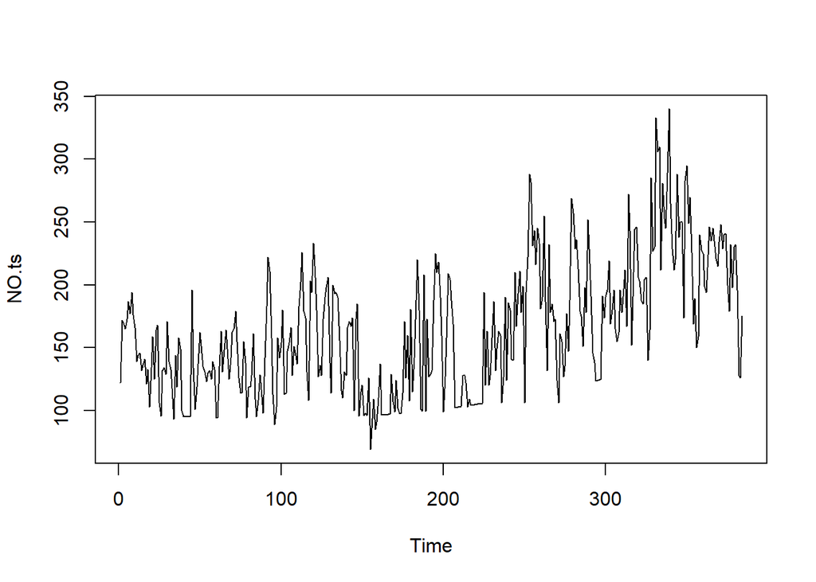

```r
# create time series
NO.ts <- ts(air.train$NO2.GT.)

# visualize raw data
plot(NO.ts)
```

There appears to be an increasing trend, especially after about t = 150. There is also the potential for seasonality, but this fluctuation could instead be random.

```r
# periodogram
pg.NO <- spec.pgram(NO.ts, spans = 9, demean = T, log = 'no')
```

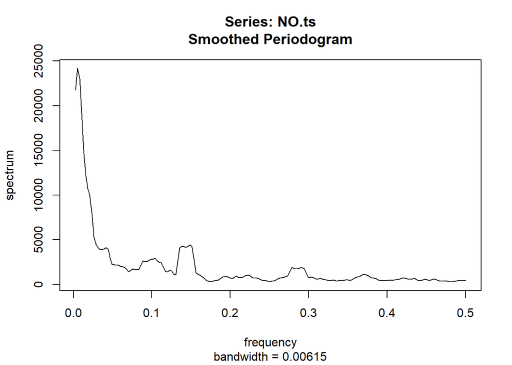

Based on the periodogram, there are multiple possibilities for the period of a seasonal component. There are fewer spikes than the periodogram for CO. There are still spikes, though, each of which indicate a possible frequency to explain the seasonality of the data. We predict that if seasonality is significant in the model, it will be based on a complex wave.

## Seasonality

### Finding Potential Periods

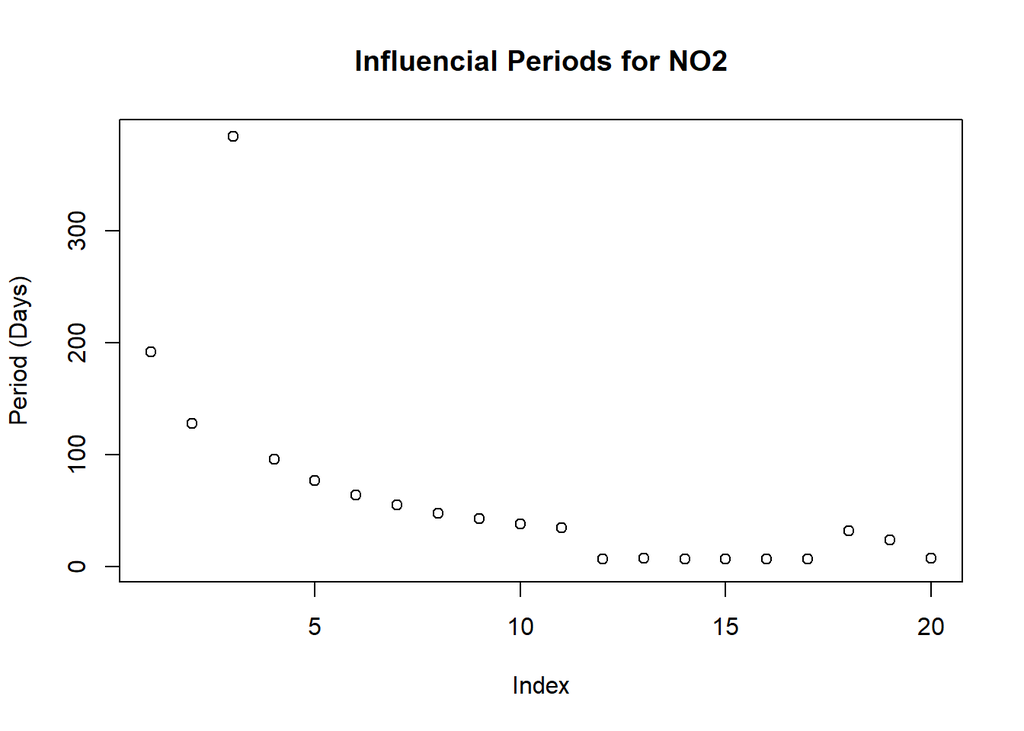

```r
# sort the frequencies based on influence
sorted.spec.NO <- sort(pg.NO$spec, decreasing = T, index.return=T)

# convert to periods
sorted.omegas.NO <- pg.NO$freq[sorted.spec.NO$ix]
sorted.Ts.NO <- 1/pg.NO$freq[sorted.spec.NO$ix]

# visualize the most influencial periods
plot(sorted.Ts.NO, xlim = c(1,20), main="Influencial Periods for NO2", xlab="Index", ylab="Period (Days)")
```

```r
# the cutoff for influential
NO.pg.cutoff <- 15

# the top periods
print('top periods')
```

```
## [1] "top periods"
```

```r
sorted.Ts.NO[1:NO.pg.cutoff]
```

```
##  [1] 192.000000 128.000000 384.000000  96.000000  76.800000  64.000000
##  [7]  54.857143  48.000000  42.666667  38.400000  34.909091   6.736842
## [13]   7.245283   6.620690   7.111111
```

```r
# top frequencies
## to double check that this makes sense based on periodogram
print('top frequencies')
```

```
## [1] "top frequencies"
```

```r
sorted.omegas.NO[1:NO.pg.cutoff]
```

```
##  [1] 0.005208333 0.007812500 0.002604167 0.010416667 0.013020833
##  [6] 0.015625000 0.018229167 0.020833333 0.023437500 0.026041667
## [11] 0.028645833 0.148437500 0.138020833 0.151041667 0.140625000
```

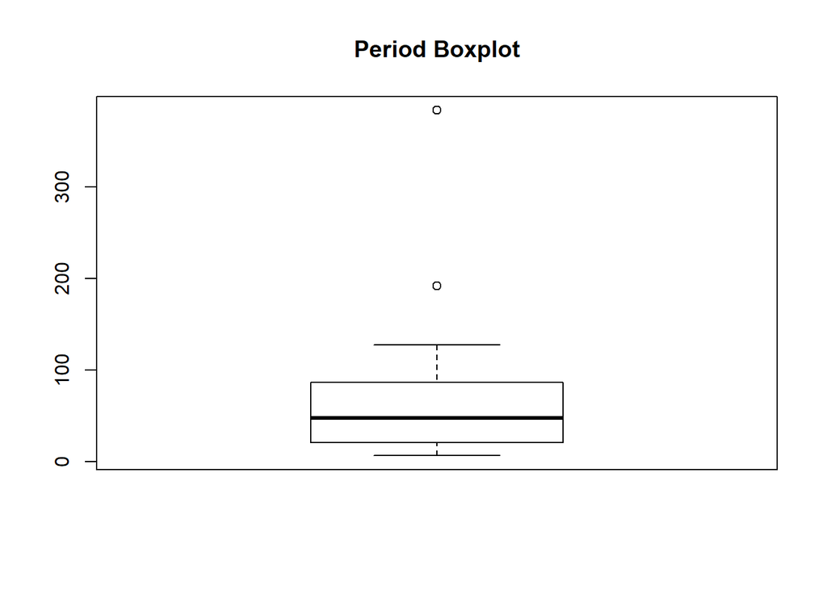

```r
# visual
NO.pg.box <- boxplot(sorted.Ts.NO[1:NO.pg.cutoff], main="Period Boxplot")
```

```r
# the average influential period
print('mean of top periods')
```

```
## [1] "mean of top periods"
```

```r
NO.pg.box.mean <- NO.pg.box$stats[3]
print(NO.pg.box.mean)
```

```
## [1] 48
```

### Create Models with Potential Periods

We created models with the top 3, 5, 10, and 15 periods, to determine which was best to explain the seasonality of the data. We did this because we predicted that the seasonality would be based on a complex wave, and we wanted to know how many different periods would be advantageous (i.e. explain more variance) in a model.  
We also created a model that used a period that was the average of several other periods that were close together. We noticed that top periods 8 through 11 were in the range of 34 to 48. We noticed that top periods 12 through 15 were all close to 7. We thought that since these sets of periods were clustered together, potentially their average would be better at explaining the variance in the model instead of adding separate predictors for each similar period.

```r
# assign top periods to variables
NO.p1 <- sorted.Ts.NO[1]
NO.p2 <- sorted.Ts.NO[2]
NO.p3 <- sorted.Ts.NO[3]
NO.p4 <- sorted.Ts.NO[4]
NO.p5 <- sorted.Ts.NO[5]
NO.p6 <- sorted.Ts.NO[6]
NO.p7 <- sorted.Ts.NO[7]
NO.p8 <- sorted.Ts.NO[8]
NO.p9 <- sorted.Ts.NO[9]
NO.p10 <- sorted.Ts.NO[10]
NO.p11 <- sorted.Ts.NO[11]
NO.p12 <- sorted.Ts.NO[12]
NO.p13 <- sorted.Ts.NO[13]
NO.p14 <- sorted.Ts.NO[14]
NO.p15 <- sorted.Ts.NO[15]

# average the periods that are clustered
NO.pavg1 <- mean(c(sorted.Ts.NO[8],sorted.Ts.NO[9], sorted.Ts.NO[10], sorted.Ts.NO[11]))
NO.pavg2 <- mean(c(sorted.Ts.NO[12],sorted.Ts.NO[13], sorted.Ts.NO[14], sorted.Ts.NO[15]))
```

Model with Top 3 Periods

```r
# create time variable
time.NO<-c(1:length(NO.ts))

# model
NO.lm.top3 <- lm(NO.ts ~ sin(2*pi*time.NO/NO.p1) +
                         cos(2*pi*time.NO/NO.p1) +
                         sin(2*pi*time.NO/NO.p2) +
                         cos(2*pi*time.NO/NO.p2) +
                         sin(2*pi*time.NO/NO.p3) +
                         cos(2*pi*time.NO/NO.p3))
```

Model with Top 5 Periods

```r
# model
NO.lm.top5 <- lm(NO.ts ~ sin(2*pi*time.NO/NO.p1) +
                         cos(2*pi*time.NO/NO.p1) +
                         sin(2*pi*time.NO/NO.p2) +
                         cos(2*pi*time.NO/NO.p2) +
                         sin(2*pi*time.NO/NO.p3) +
                         cos(2*pi*time.NO/NO.p3) +
                         sin(2*pi*time.NO/NO.p4) +
                         cos(2*pi*time.NO/NO.p4) +
                         sin(2*pi*time.NO/NO.p5) +
                         cos(2*pi*time.NO/NO.p5))
```

Model with Top 10 Periods

```r
# model
NO.lm.top10 <- lm(NO.ts ~ sin(2*pi*time.NO/NO.p1) +
                         cos(2*pi*time.NO/NO.p1) +
                         sin(2*pi*time.NO/NO.p2) +
                         cos(2*pi*time.NO/NO.p2) +
                         sin(2*pi*time.NO/NO.p3) +
                         cos(2*pi*time.NO/NO.p3) +
                         sin(2*pi*time.NO/NO.p4) +
                         cos(2*pi*time.NO/NO.p4) +
                         sin(2*pi*time.NO/NO.p5) +
                         cos(2*pi*time.NO/NO.p5) +
                         sin(2*pi*time.NO/NO.p6) +
                         cos(2*pi*time.NO/NO.p6) +
                         sin(2*pi*time.NO/NO.p7) +
                         cos(2*pi*time.NO/NO.p7) +
                         sin(2*pi*time.NO/NO.p8) +
                         cos(2*pi*time.NO/NO.p8) +
                         sin(2*pi*time.NO/NO.p9) +
                         cos(2*pi*time.NO/NO.p9) +
                         sin(2*pi*time.NO/NO.p10) +
                         cos(2*pi*time.NO/NO.p10))
```

Model with Top 15 Periods

```r
# model
NO.lm.top15 <- lm(NO.ts ~ sin(2*pi*time.NO/NO.p1) +
                         cos(2*pi*time.NO/NO.p1) +
                         sin(2*pi*time.NO/NO.p2) +
                         cos(2*pi*time.NO/NO.p2) +
                         sin(2*pi*time.NO/NO.p3) +
                         cos(2*pi*time.NO/NO.p3) +
                         sin(2*pi*time.NO/NO.p4) +
                         cos(2*pi*time.NO/NO.p4) +
                         sin(2*pi*time.NO/NO.p5) +
                         cos(2*pi*time.NO/NO.p5) +
                         sin(2*pi*time.NO/NO.p6) +
                         cos(2*pi*time.NO/NO.p6) +
                         sin(2*pi*time.NO/NO.p7) +
                         cos(2*pi*time.NO/NO.p7) +
                         sin(2*pi*time.NO/NO.p8) +
                         cos(2*pi*time.NO/NO.p8) +
                         sin(2*pi*time.NO/NO.p9) +
                         cos(2*pi*time.NO/NO.p9) +
                         sin(2*pi*time.NO/NO.p10) +
                         cos(2*pi*time.NO/NO.p10) +
                         sin(2*pi*time.NO/NO.p11) +
                         cos(2*pi*time.NO/NO.p11) +
                         sin(2*pi*time.NO/NO.p12) +
                         cos(2*pi*time.NO/NO.p12) +
                         sin(2*pi*time.NO/NO.p13) +
                         cos(2*pi*time.NO/NO.p13) +
                         sin(2*pi*time.NO/NO.p14) +
                         cos(2*pi*time.NO/NO.p14) +
                         sin(2*pi*time.NO/NO.p15) +
                         cos(2*pi*time.NO/NO.p15))
```

Model with Averaged Periods

```r
NO.lm.combined <- lm(NO.ts ~ sin(2*pi*time.NO/NO.p1) +
                         cos(2*pi*time.NO/NO.p1) +
                         sin(2*pi*time.NO/NO.p2) +
                         cos(2*pi*time.NO/NO.p2) +
                         sin(2*pi*time.NO/NO.p3) +
                         cos(2*pi*time.NO/NO.p3) +
                         sin(2*pi*time.NO/NO.p4) +
                         cos(2*pi*time.NO/NO.p4) +
                         sin(2*pi*time.NO/NO.p5) +
                         cos(2*pi*time.NO/NO.p5) +
                         sin(2*pi*time.NO/NO.p6) +
                         cos(2*pi*time.NO/NO.p6) +
                         sin(2*pi*time.NO/NO.p7) +
                         cos(2*pi*time.NO/NO.p7) +
                         sin(2*pi*time.NO/NO.pavg1) +
                         cos(2*pi*time.NO/NO.pavg1) +
                         sin(2*pi*time.NO/NO.pavg2) +
                         cos(2*pi*time.NO/NO.pavg2))
```

### Model Comparison

```r
anova(NO.lm.top3, NO.lm.top5)
```

```
## Analysis of Variance Table
##
## Model 1: NO.ts ~ sin(2 * pi * time.NO/NO.p1) + cos(2 * pi * time.NO/NO.p1) +
##     sin(2 * pi * time.NO/NO.p2) + cos(2 * pi * time.NO/NO.p2) +
##     sin(2 * pi * time.NO/NO.p3) + cos(2 * pi * time.NO/NO.p3)
## Model 2: NO.ts ~ sin(2 * pi * time.NO/NO.p1) + cos(2 * pi * time.NO/NO.p1) +
##     sin(2 * pi * time.NO/NO.p2) + cos(2 * pi * time.NO/NO.p2) +
##     sin(2 * pi * time.NO/NO.p3) + cos(2 * pi * time.NO/NO.p3) +
##     sin(2 * pi * time.NO/NO.p4) + cos(2 * pi * time.NO/NO.p4) +
##     sin(2 * pi * time.NO/NO.p5) + cos(2 * pi * time.NO/NO.p5)
##   Res.Df    RSS Df Sum of Sq      F    Pr(>F)
## 1    377 553038
## 2    373 497754  4     55284 10.357 5.789e-08 ***
## ---
## Signif. codes:  0 '***' 0.001 '**' 0.01 '*' 0.05 '.' 0.1 ' ' 1
```

```r
# small p-value suggests that the larger model performs better than the smaller model

anova(NO.lm.top5, NO.lm.top10)
```

```
## Analysis of Variance Table
##
## Model 1: NO.ts ~ sin(2 * pi * time.NO/NO.p1) + cos(2 * pi * time.NO/NO.p1) +
##     sin(2 * pi * time.NO/NO.p2) + cos(2 * pi * time.NO/NO.p2) +
##     sin(2 * pi * time.NO/NO.p3) + cos(2 * pi * time.NO/NO.p3) +
##     sin(2 * pi * time.NO/NO.p4) + cos(2 * pi * time.NO/NO.p4) +
##     sin(2 * pi * time.NO/NO.p5) + cos(2 * pi * time.NO/NO.p5)
## Model 2: NO.ts ~ sin(2 * pi * time.NO/NO.p1) + cos(2 * pi * time.NO/NO.p1) +
##     sin(2 * pi * time.NO/NO.p2) + cos(2 * pi * time.NO/NO.p2) +
##     sin(2 * pi * time.NO/NO.p3) + cos(2 * pi * time.NO/NO.p3) +
##     sin(2 * pi * time.NO/NO.p4) + cos(2 * pi * time.NO/NO.p4) +
##     sin(2 * pi * time.NO/NO.p5) + cos(2 * pi * time.NO/NO.p5) +
##     sin(2 * pi * time.NO/NO.p6) + cos(2 * pi * time.NO/NO.p6) +
##     sin(2 * pi * time.NO/NO.p7) + cos(2 * pi * time.NO/NO.p7) +
##     sin(2 * pi * time.NO/NO.p8) + cos(2 * pi * time.NO/NO.p8) +
##     sin(2 * pi * time.NO/NO.p9) + cos(2 * pi * time.NO/NO.p9) +
##     sin(2 * pi * time.NO/NO.p10) + cos(2 * pi * time.NO/NO.p10)
##   Res.Df    RSS Df Sum of Sq      F    Pr(>F)
## 1    373 497754
## 2    363 421534 10     76220 6.5636 2.357e-09 ***
## ---
## Signif. codes:  0 '***' 0.001 '**' 0.01 '*' 0.05 '.' 0.1 ' ' 1
```

```r
# small p-value suggests that the larger model performs better than the smaller model

anova(NO.lm.top10, NO.lm.top15)
```

```
## Analysis of Variance Table
##
## Model 1: NO.ts ~ sin(2 * pi * time.NO/NO.p1) + cos(2 * pi * time.NO/NO.p1) +
##     sin(2 * pi * time.NO/NO.p2) + cos(2 * pi * time.NO/NO.p2) +
##     sin(2 * pi * time.NO/NO.p3) + cos(2 * pi * time.NO/NO.p3) +
##     sin(2 * pi * time.NO/NO.p4) + cos(2 * pi * time.NO/NO.p4) +
##     sin(2 * pi * time.NO/NO.p5) + cos(2 * pi * time.NO/NO.p5) +
##     sin(2 * pi * time.NO/NO.p6) + cos(2 * pi * time.NO/NO.p6) +
##     sin(2 * pi * time.NO/NO.p7) + cos(2 * pi * time.NO/NO.p7) +
##     sin(2 * pi * time.NO/NO.p8) + cos(2 * pi * time.NO/NO.p8) +
##     sin(2 * pi * time.NO/NO.p9) + cos(2 * pi * time.NO/NO.p9) +
##     sin(2 * pi * time.NO/NO.p10) + cos(2 * pi * time.NO/NO.p10)
## Model 2: NO.ts ~ sin(2 * pi * time.NO/NO.p1) + cos(2 * pi * time.NO/NO.p1) +
##     sin(2 * pi * time.NO/NO.p2) + cos(2 * pi * time.NO/NO.p2) +
##     sin(2 * pi * time.NO/NO.p3) + cos(2 * pi * time.NO/NO.p3) +
##     sin(2 * pi * time.NO/NO.p4) + cos(2 * pi * time.NO/NO.p4) +
##     sin(2 * pi * time.NO/NO.p5) + cos(2 * pi * time.NO/NO.p5) +
##     sin(2 * pi * time.NO/NO.p6) + cos(2 * pi * time.NO/NO.p6) +
##     sin(2 * pi * time.NO/NO.p7) + cos(2 * pi * time.NO/NO.p7) +
##     sin(2 * pi * time.NO/NO.p8) + cos(2 * pi * time.NO/NO.p8) +
##     sin(2 * pi * time.NO/NO.p9) + cos(2 * pi * time.NO/NO.p9) +
##     sin(2 * pi * time.NO/NO.p10) + cos(2 * pi * time.NO/NO.p10) +
##     sin(2 * pi * time.NO/NO.p11) + cos(2 * pi * time.NO/NO.p11) +
##     sin(2 * pi * time.NO/NO.p12) + cos(2 * pi * time.NO/NO.p12) +
##     sin(2 * pi * time.NO/NO.p13) + cos(2 * pi * time.NO/NO.p13) +
##     sin(2 * pi * time.NO/NO.p14) + cos(2 * pi * time.NO/NO.p14) +
##     sin(2 * pi * time.NO/NO.p15) + cos(2 * pi * time.NO/NO.p15)
##   Res.Df    RSS Df Sum of Sq     F Pr(>F)
## 1    363 421534
## 2    353 411452 10     10082 0.865 0.5664
```

```r
# large p-value suggests that the smaller model performs better

anova(NO.lm.top10, NO.lm.combined)
```

```
## Analysis of Variance Table
##
## Model 1: NO.ts ~ sin(2 * pi * time.NO/NO.p1) + cos(2 * pi * time.NO/NO.p1) +
##     sin(2 * pi * time.NO/NO.p2) + cos(2 * pi * time.NO/NO.p2) +
##     sin(2 * pi * time.NO/NO.p3) + cos(2 * pi * time.NO/NO.p3) +
##     sin(2 * pi * time.NO/NO.p4) + cos(2 * pi * time.NO/NO.p4) +
##     sin(2 * pi * time.NO/NO.p5) + cos(2 * pi * time.NO/NO.p5) +
##     sin(2 * pi * time.NO/NO.p6) + cos(2 * pi * time.NO/NO.p6) +
##     sin(2 * pi * time.NO/NO.p7) + cos(2 * pi * time.NO/NO.p7) +
##     sin(2 * pi * time.NO/NO.p8) + cos(2 * pi * time.NO/NO.p8) +
##     sin(2 * pi * time.NO/NO.p9) + cos(2 * pi * time.NO/NO.p9) +
##     sin(2 * pi * time.NO/NO.p10) + cos(2 * pi * time.NO/NO.p10)
## Model 2: NO.ts ~ sin(2 * pi * time.NO/NO.p1) + cos(2 * pi * time.NO/NO.p1) +
##     sin(2 * pi * time.NO/NO.p2) + cos(2 * pi * time.NO/NO.p2) +
##     sin(2 * pi * time.NO/NO.p3) + cos(2 * pi * time.NO/NO.p3) +
##     sin(2 * pi * time.NO/NO.p4) + cos(2 * pi * time.NO/NO.p4) +
##     sin(2 * pi * time.NO/NO.p5) + cos(2 * pi * time.NO/NO.p5) +
##     sin(2 * pi * time.NO/NO.p6) + cos(2 * pi * time.NO/NO.p6) +
##     sin(2 * pi * time.NO/NO.p7) + cos(2 * pi * time.NO/NO.p7) +
##     sin(2 * pi * time.NO/NO.pavg1) + cos(2 * pi * time.NO/NO.pavg1) +
##     sin(2 * pi * time.NO/NO.pavg2) + cos(2 * pi * time.NO/NO.pavg2)
##   Res.Df    RSS Df Sum of Sq      F Pr(>F)
## 1    363 421534
## 2    365 424611 -2   -3077.2 1.3249 0.2671
```

```r
# large p-value suggests that the smaller model performs better
```

The partial F tests suggest that the model that includes the top 10 periods is better than the models with 3, 5, and 15 periods. The partial F test also suggests that the model with the averaged periods is better than the model with the top 10 periods. Both the model with 10 periods and the model with averaged periods will be further compared through metrics and diagnostics later, after we determine if there is a significant trend to be included.

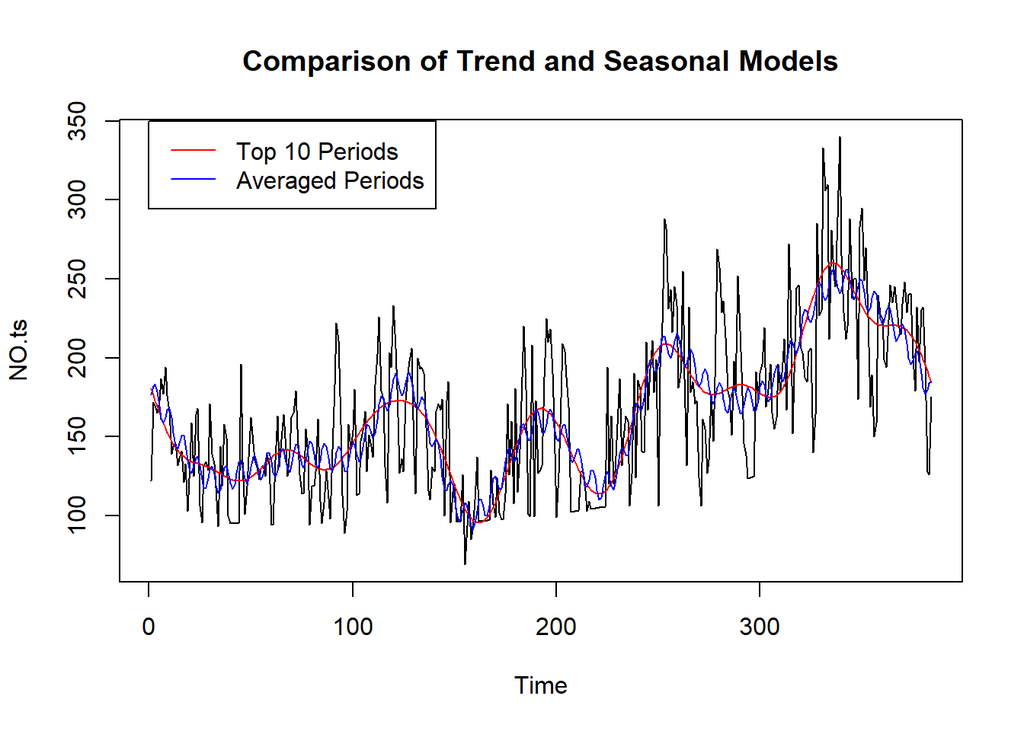

```r
# visualize
plot(NO.ts, main = "Comparison of Trend and Seasonal Models")
lines(NO.lm.top10$fitted.values, col = "red")
lines(NO.lm.combined$fitted.values, col = "blue")

legend(0, 350, legend = c("Top 10 Periods", "Averaged Periods"), col = c("red", "blue"), lwd = 1)
```

Upon visual inspection, both models get the basic shape of the time series correct, though the model with the averaged periods has smaller fluctuations that may better match the actual data.

## Trend

### Model Time Series Based on Time

```r
# trend model
NO.lm.trend <- lm(NO.ts ~ time.NO)

# summary analysis
summary(NO.lm.trend)
```

```
##
## Call:
## lm(formula = NO.ts ~ time.NO)
##
## Residuals:
##     Min      1Q  Median      3Q     Max
## -87.389 -34.365   2.159  27.847 137.895
##
## Coefficients:
##              Estimate Std. Error t value Pr(>|t|)
## (Intercept) 115.16473    4.40111   26.17   <2e-16 ***
## time.NO       0.25646    0.01981   12.94   <2e-16 ***
## ---
## Signif. codes:  0 '***' 0.001 '**' 0.01 '*' 0.05 '.' 0.1 ' ' 1
##
## Residual standard error: 43.04 on 382 degrees of freedom
## Multiple R-squared:  0.3049, Adjusted R-squared:  0.3031
## F-statistic: 167.6 on 1 and 382 DF,  p-value: < 2.2e-16
```

The p-value is significant at the 0.05 level, which means that the trend is significant.

### Visualize Trend

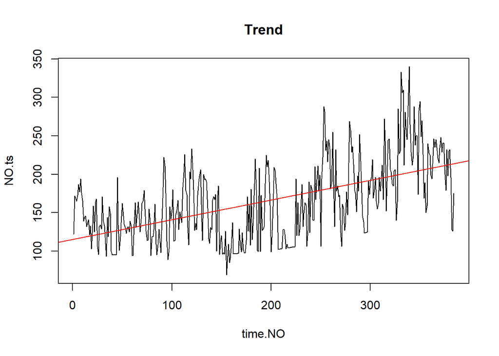

```r
plot(time.NO, NO.ts, type = "l", main = "Trend")
abline(NO.lm.trend, col = "red")
```

As we noticed earlier from looking at the time series, there is an upward trend to the data.

### Model Comparison: Trend and Seasonality Together

```r
# model with trend + averaged periods
NO.seasonalavg.trend <- lm(NO.ts ~ time.NO + sin(2*pi*time.NO/NO.p1) +
                         cos(2*pi*time.NO/NO.p1) +
                         sin(2*pi*time.NO/NO.p2) +
                         cos(2*pi*time.NO/NO.p2) +
                         sin(2*pi*time.NO/NO.p3) +
                         cos(2*pi*time.NO/NO.p3) +
                         sin(2*pi*time.NO/NO.p4) +
                         cos(2*pi*time.NO/NO.p4) +
                         sin(2*pi*time.NO/NO.p5) +
                         cos(2*pi*time.NO/NO.p5) +
                         sin(2*pi*time.NO/NO.p6) +
                         cos(2*pi*time.NO/NO.p6) +
                         sin(2*pi*time.NO/NO.p7) +
                         cos(2*pi*time.NO/NO.p7) +
                         sin(2*pi*time.NO/NO.pavg1) +
                         cos(2*pi*time.NO/NO.pavg1) +
                         sin(2*pi*time.NO/NO.pavg2) +
                         cos(2*pi*time.NO/NO.pavg2))

# model with trend + 10 periods
NO.seasonal10.trend <- lm(NO.ts ~ time.NO + sin(2*pi*time.NO/NO.p1) +
                         cos(2*pi*time.NO/NO.p1) +
                         sin(2*pi*time.NO/NO.p2) +
                         cos(2*pi*time.NO/NO.p2) +
                         sin(2*pi*time.NO/NO.p3) +
                         cos(2*pi*time.NO/NO.p3) +
                         sin(2*pi*time.NO/NO.p4) +
                         cos(2*pi*time.NO/NO.p4) +
                         sin(2*pi*time.NO/NO.p5) +
                         cos(2*pi*time.NO/NO.p5) +
                         sin(2*pi*time.NO/NO.p6) +
                         cos(2*pi*time.NO/NO.p6) +
                         sin(2*pi*time.NO/NO.p7) +
                         cos(2*pi*time.NO/NO.p7) +
                         sin(2*pi*time.NO/NO.p8) +
                         cos(2*pi*time.NO/NO.p8) +
                         sin(2*pi*time.NO/NO.p9) +
                         cos(2*pi*time.NO/NO.p9) +
                         sin(2*pi*time.NO/NO.p10) +
                         cos(2*pi*time.NO/NO.p10))
```

#### Visual Comparison

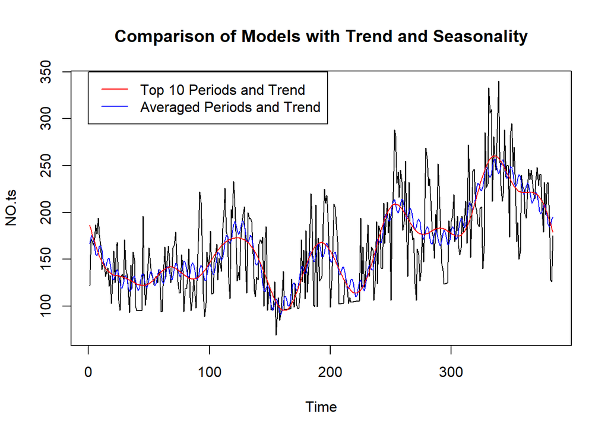

```r
plot(NO.ts, main = "Comparison of Models with Trend and Seasonality")
lines(NO.seasonalavg.trend$fitted.values, col = "blue")
lines(NO.seasonal10.trend$fitted.values, col = "red")
legend(0, 350, legend = c("Top 10 Periods and Trend", "Averaged Periods and Trend"), col = c("red", "blue"),
       lwd = 1)
```

Based on visual inspection, the model with trend and averaged periods appears to better capture the fluctuations of the data, though both models match the general trend of the data.

#### Comparison Using Metrics

```r
# Adjusted R^2: model with trend and averaged periods
print('Adjusted R^2: model with trend and averaged periods')
```

```
## [1] "Adjusted R^2: model with trend and averaged periods"
```

```r
summary(NO.seasonalavg.trend)$adj.r.squared
```

```
## [1] 0.5622059
```

```r
# AIC: model with trend and averaged periods
print('AIC: model with trend and averaged periods')
```

```
## [1] "AIC: model with trend and averaged periods"
```

```r
AIC(NO.seasonalavg.trend)
```

```
## [1] 3821.945
```

```r
# Adjusted R^2: model with trend and 10 periods
print('Adjusted R^2: model with trend and 10 periods')
```

```
## [1] "Adjusted R^2: model with trend and 10 periods"
```

```r
summary(NO.seasonal10.trend)$adj.r.squared
```

```
## [1] 0.5621247
```

```r
# AIC: model with trend and 10 periods
print('AIC: model with trend and 10 periods')
```

```
## [1] "AIC: model with trend and 10 periods"
```

```r
AIC(NO.seasonal10.trend)
```

```
## [1] 3823.9
```

The adjusted R^2 of the model that includes the trend and averaged periods is 0.5622. The adjusted R^2 of the model that includes the trend and 10 periods is 0.5621. Based on adjusted R^2, the models are essentially equivalent.  
The AIC of the model with averaged periods is 3821.945. The AIC of the model with 10 periods is 3823.9. Based on AIC, we would choose the model with averaged periods, because it has the smaller AIC value. The values are very similar, though.

#### Diagnostics

**Residuals vs. Fitted**

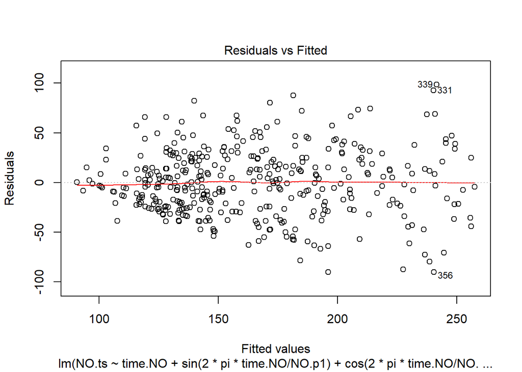

```r
plot(NO.seasonalavg.trend, which = 1)
```

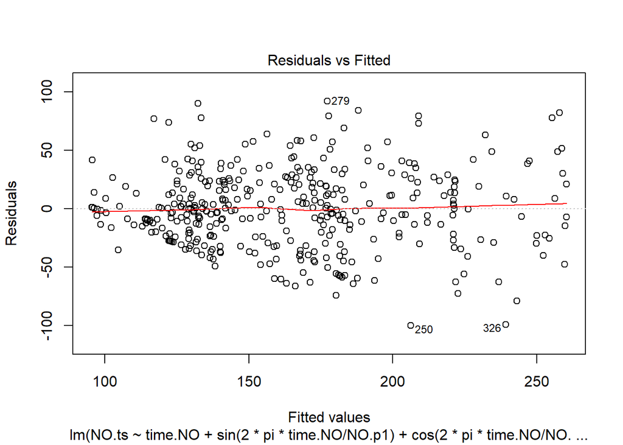

```r
plot(NO.seasonal10.trend, which = 1)
```

The mean of the residuals is approximately 0 and has fairly even spread above and below the x-axis for both models. The variance appears to have a slight trend, where there is less spread above and below the x-axis to the left and slightly more on the right.

**QQ Plot**

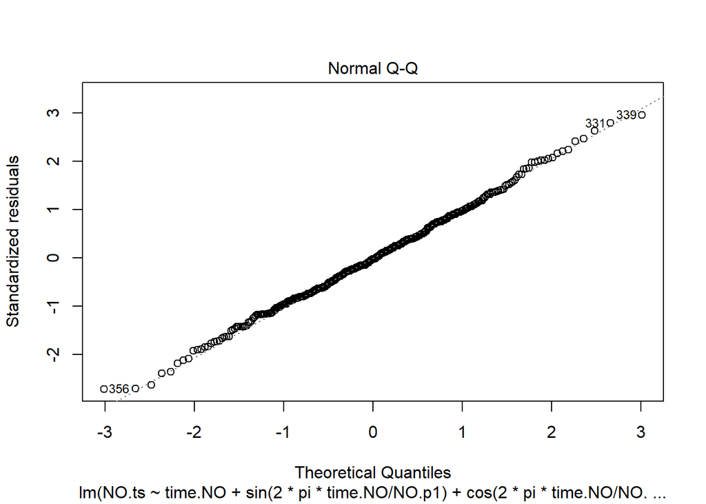

```r
plot(NO.seasonalavg.trend, which = 2)
```

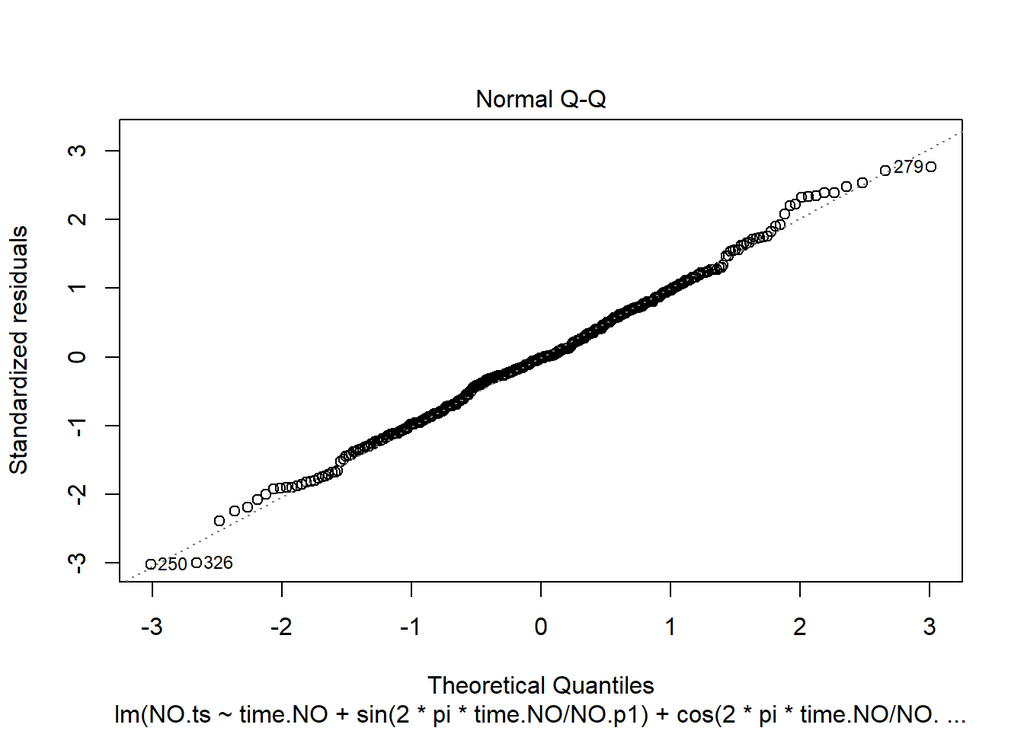

```r
plot(NO.seasonal10.trend, which = 2)
```

The residuals are approximately normal for both models, though the tails show some deviation from normality. The model with averaged periods appears to have slightly more normal residuals at the tails.

**Scale-Location Plot**

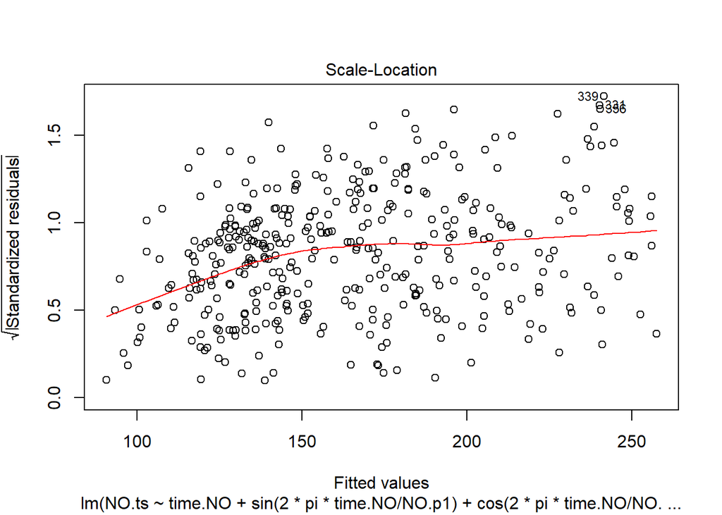

```r
plot(NO.seasonalavg.trend, which = 3)
```

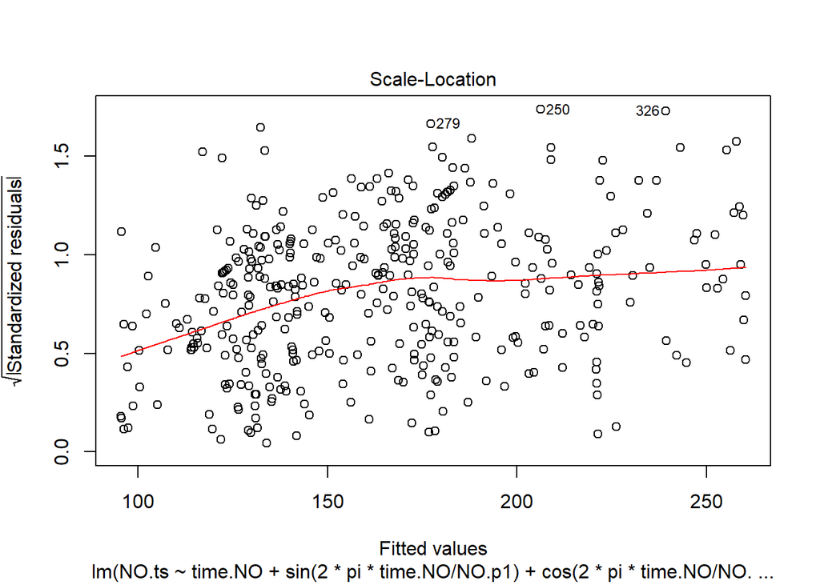

```r
plot(NO.seasonal10.trend, which = 3)
```

While the mean is not centered at 0 for either plot, there appears to be relatively good spread in both plots.

**Residuals vs. Leverage**

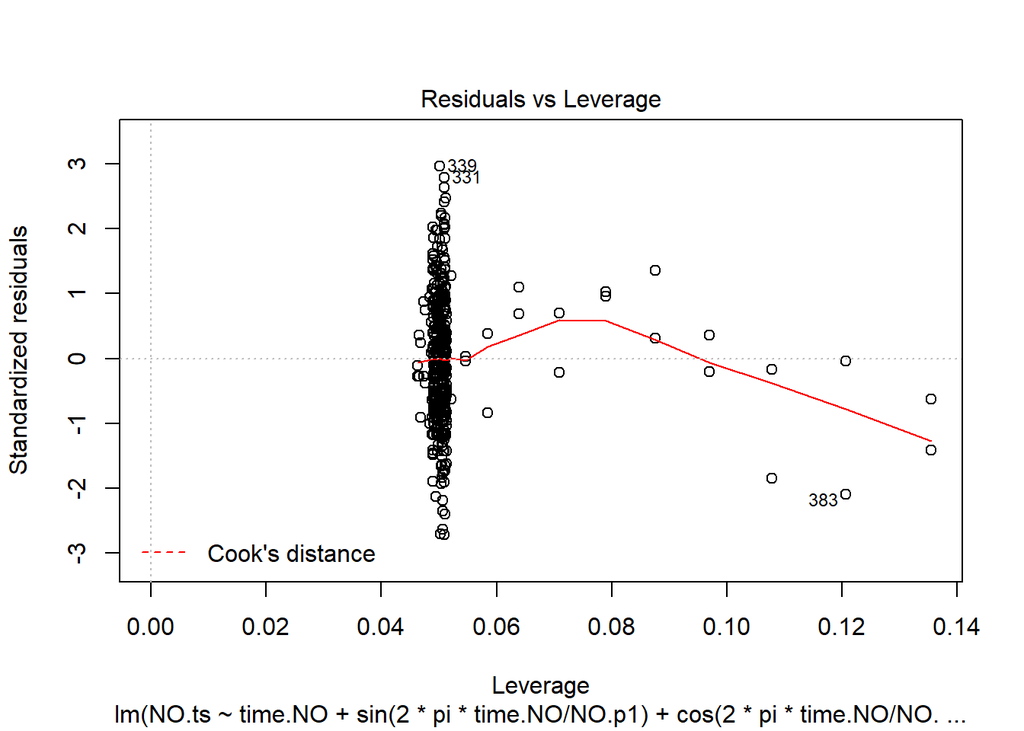

```r
plot(NO.seasonalavg.trend, which = 5)
```

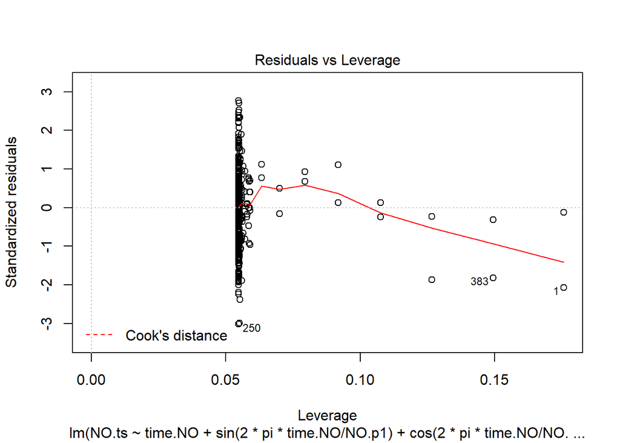

```r
plot(NO.seasonal10.trend, which = 5)
```

Neither plot has any points with Cook’s distances greater than 0.5.

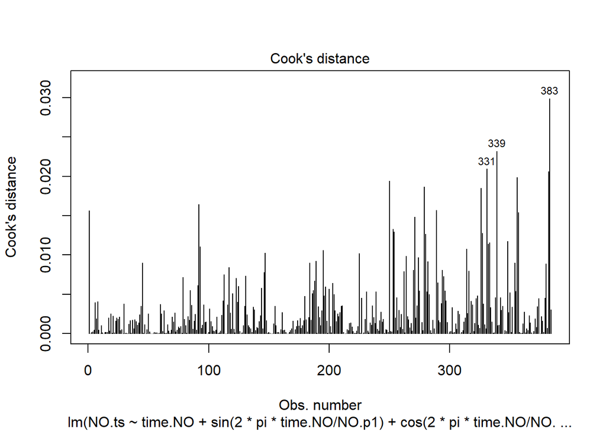

```r
# plot Cook's distances
plot(NO.seasonalavg.trend,labels.id = NULL, which = 4)
```

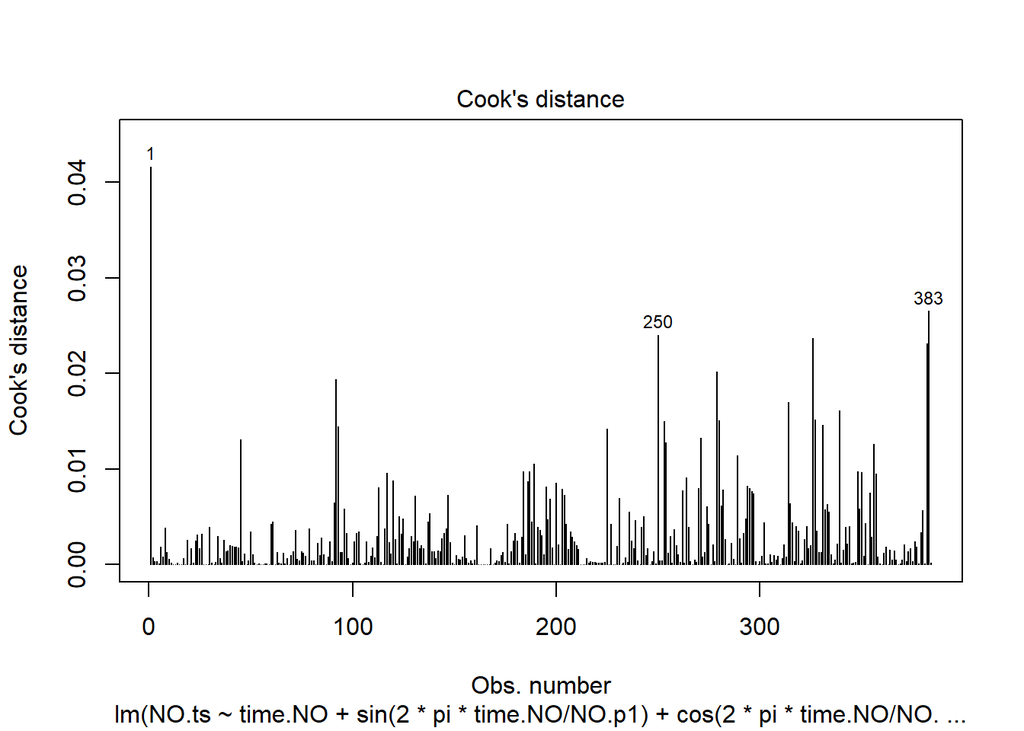

```r
plot(NO.seasonal10.trend,labels.id = NULL, which = 4)
```

Both models have low Cook’s distances for all points.

Both models perform similarly in the diagnostics. We do not feel that either model needs a log or Box Cox transformation to improve the diagnostics.

### Choose Trend + Seasonal Model

```r
NO.lm <- NO.seasonalavg.trend
```

We have chosen the model with the trend and averaged periods to explain seasonality, as it performed slightly better in AIC than the model with trend and 10 periods, as well as being preferred after the partial F test. Since the diagnostics for both models were similar, AIC and the partial F test were used to make the decision. Though not a deciding factor in our choice, this model also has the advantage of having somewhat more normal residuals in the tails of the QQ plot.

## Model Residuals

### ACF and PACF

```r
# ACF and PACF
acf(NO.ts)
```

[output not shown]

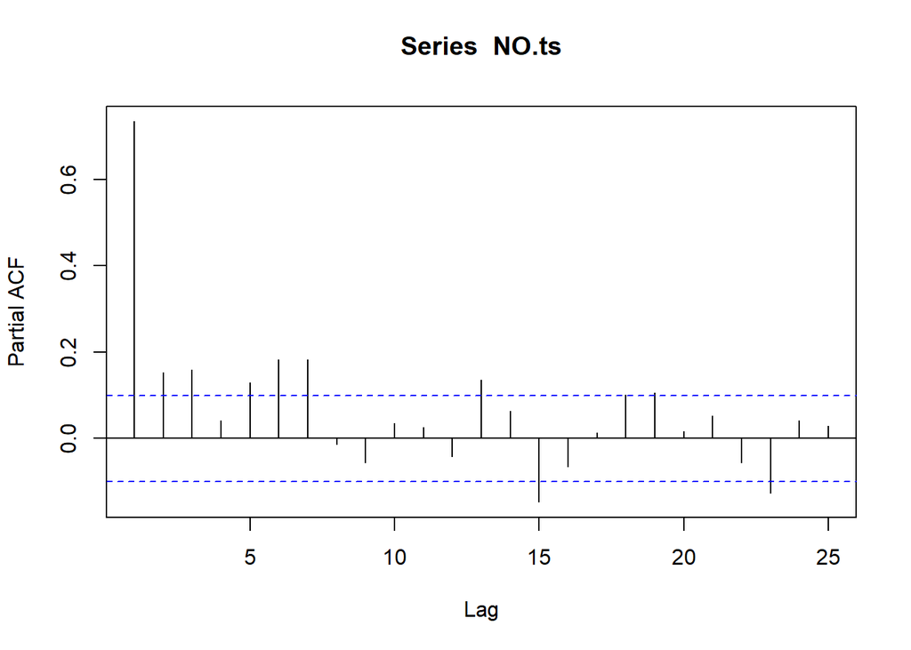

```r
pacf(NO.ts)
```

The ACF has somewhat sinusoidal behavior and is significant for all 25 lags in view on the plot. The first few lags could be seen as having linear decay, suggesting that the time series may not be stationary and the first differences may need to be taken to meet the stationarity assumption. Values for d of 0 and 1 will be tested in potential models.

The PACF does not cut off after a certain number of lags and also has somewhat sinusoidal behavior. We predict that there will be autoregressive and moving average terms in the model of the residuals.

Based on the PACF, a potential value for p for the autoregressive portion of the model is 3. We will also test values of 1 and 2 for p, since they are the other significant lags before the first cutoff in the PACF.  
Based on the ACF, a potential value for q for the moving average portion of the model is 4. This is the point where the ACF stops decreasing, before increasing again, for the first time. Values of 1, 2, and 3 will also be tested for q, as these lags are also significant before the lag of 4.

### ARIMA Models

We tested the possible combinations of our p, d, and q values.

```r
# get residuals
e.ts.NO <-ts(NO.lm$residuals)

# create arima models based on the residuals

# 1, 0, 1
NO.arima101 <- arima(e.ts.NO, order = c(1,0,1), include.mean = FALSE)
summary(NO.arima101)
```

```
##
## Call:
## arima(x = e.ts.NO, order = c(1, 0, 1), include.mean = FALSE)
##
## Coefficients:
##          ar1     ma1
##       0.2752  0.1179
## s.e.  0.1392  0.1456
##
## sigma^2 estimated as 945:  log likelihood = -1860.39,  aic = 3726.77
##
## Training set error measures:
##                        ME     RMSE      MAE      MPE     MAPE      MASE
## Training set -0.004790035 30.74157 24.23745 86.79421 137.8758 0.8724626
##                      ACF1
## Training set -0.001568528
```

```r
# AIC = 3726.77

# 1, 0, 2
NO.arima102 <- arima(e.ts.NO, order = c(1,0,2), include.mean = FALSE)
summary(NO.arima102)
```

```
##
## Call:
## arima(x = e.ts.NO, order = c(1, 0, 2), include.mean = FALSE)
##
## Coefficients:
##          ar1     ma1      ma2
##       0.3184  0.0755  -0.0207
## s.e.  0.2502  0.2505   0.1061
##
## sigma^2 estimated as 944.9:  log likelihood = -1860.37,  aic = 3728.74
##
## Training set error measures:
##                        ME  RMSE      MAE     MPE     MAPE      MASE
## Training set -0.005851891 30.74 24.23397 87.2972 137.6968 0.8723372
##                      ACF1
## Training set -0.001778526
```

```r
# AIC = 3728.74

# 1, 0, 3
NO.arima103 <- arima(e.ts.NO, order = c(1,0,3), include.mean = FALSE)
summary(NO.arima103)
```

```
##
## Call:
## arima(x = e.ts.NO, order = c(1, 0, 3), include.mean = FALSE)
##
## Coefficients:
##           ar1     ma1     ma2     ma3
##       -0.0635  0.4581  0.1542  0.1201
## s.e.   0.2860  0.2807  0.1122  0.0636
##
## sigma^2 estimated as 938.7:  log likelihood = -1859.11,  aic = 3728.22
##
## Training set error measures:
##                       ME     RMSE      MAE     MPE     MAPE      MASE
## Training set -0.01218995 30.63822 24.02608 87.8098 130.2569 0.8648541
##                      ACF1
## Training set -0.001581292
```

```r
# AIC = 3728.22

# 1, 0, 4
NO.arima104 <- arima(e.ts.NO, order = c(1,0,4), include.mean = FALSE)
summary(NO.arima104)
```

```
##
## Call:
## arima(x = e.ts.NO, order = c(1, 0, 4), include.mean = FALSE)
##
## Coefficients:
##          ar1      ma1      ma2      ma3      ma4
##       0.7857  -0.5115  -0.2365  -0.0367  -0.2153
## s.e.  0.0417   0.0581   0.0585   0.0571   0.0629
##
## sigma^2 estimated as 850.7:  log likelihood = -1842.06,  aic = 3696.11
##
## Training set error measures:
##                      ME     RMSE      MAE      MPE     MAPE      MASE
## Training set 0.03387313 29.16726 22.70924 78.75416 129.5468 0.8174523
##                    ACF1
## Training set 0.01653262
```

```r
# AIC = 3696.11
# lowest

# 1, 1, 1
NO.arima111 <- arima(e.ts.NO, order = c(1,1,1), include.mean = FALSE)
summary(NO.arima111)
```

```
##
## Call:
## arima(x = e.ts.NO, order = c(1, 1, 1), include.mean = FALSE)
##
## Coefficients:
##          ar1      ma1
##       0.3799  -1.0000
## s.e.  0.0475   0.0066
##
## sigma^2 estimated as 949.2:  log likelihood = -1858.88,  aic = 3723.77
##
## Training set error measures:
##                     ME     RMSE      MAE      MPE     MAPE      MASE
## Training set 0.3978709 30.76934 24.25538 79.26134 144.9515 0.8731077
##                    ACF1
## Training set 0.01577263
```

```r
# AIC = 3723.77

# 1, 1, 2
NO.arima112 <- arima(e.ts.NO, order = c(1,1,2), include.mean = FALSE)
summary(NO.arima112)
```

```
##
## Call:
## arima(x = e.ts.NO, order = c(1, 1, 2), include.mean = FALSE)
##
## Coefficients:
##          ar1      ma1     ma2
##       0.2846  -0.8890  -0.111
## s.e.  0.1385   0.1451   0.145
##
## sigma^2 estimated as 947.5:  log likelihood = -1858.58,  aic = 3725.16
##
## Training set error measures:
##                     ME     RMSE      MAE      MPE     MAPE      MASE
## Training set 0.3978857 30.74171 24.21762 79.47537 145.2347 0.8717486
##                      ACF1
## Training set 0.0003740948
```

```r
# AIC = 3725.16

# 1, 1, 3
NO.arima113 <- arima(e.ts.NO, order = c(1,1,3), include.mean = FALSE)
summary(NO.arima113)
```

```
##
## Call:
## arima(x = e.ts.NO, order = c(1, 1, 3), include.mean = FALSE)
##
## Coefficients:
##          ar1      ma1      ma2     ma3
##       0.3258  -0.9291  -0.0914  0.0205
## s.e.  0.2453   0.2454   0.1696  0.1044
##
## sigma^2 estimated as 947.4:  log likelihood = -1858.56,  aic = 3727.12
##
## Training set error measures:
##                     ME     RMSE      MAE      MPE     MAPE      MASE
## Training set 0.3977028 30.74014 24.21454 79.99985 145.0683 0.8716378
##                     ACF1
## Training set 5.09531e-05
```

```r
# AIC = 3727.12

# 1, 1, 4
NO.arima114 <- arima(e.ts.NO, order = c(1,1,4), include.mean = FALSE)
summary(NO.arima114)
```

```
##
## Call:
## arima(x = e.ts.NO, order = c(1, 1, 4), include.mean = FALSE)
##
## Coefficients:
##           ar1      ma1      ma2      ma3      ma4
##       -0.0492  -0.5528  -0.2935  -0.0314  -0.1223
## s.e.   0.2780   0.2728   0.1846   0.0959   0.0639
##
## sigma^2 estimated as 941.2:  log likelihood = -1857.25,  aic = 3726.51
##
## Training set error measures:
##                     ME     RMSE      MAE      MPE    MAPE      MASE
## Training set 0.3940524 30.63907 24.02045 80.69848 137.941 0.8646512
##                       ACF1
## Training set -0.0001311874
```

```r
# AIC = 3726.51

# 2, 0, 1
NO.arima201 <- arima(e.ts.NO, order = c(2,0,1), include.mean = FALSE)
summary(NO.arima201)
```

```
##
## Call:
## arima(x = e.ts.NO, order = c(2, 0, 1), include.mean = FALSE)
##
## Coefficients:
##           ar1     ar2     ma1
##       -0.3978  0.2559  0.7936
## s.e.   0.2394  0.1164  0.2277
##
## sigma^2 estimated as 942.4:  log likelihood = -1859.85,  aic = 3727.69
##
## Training set error measures:
##                       ME     RMSE     MAE      MPE     MAPE      MASE
## Training set -0.01030572 30.69773 24.1311 88.55227 132.7114 0.8686343
##                      ACF1
## Training set -0.001055449
```

```r
# AIC = 3727.69

# 2, 0, 2
NO.arima202 <- arima(e.ts.NO, order = c(2,0,2), include.mean = FALSE)
summary(NO.arima202)
```

```
##
## Call:
## arima(x = e.ts.NO, order = c(2, 0, 2), include.mean = FALSE)
##
## Coefficients:
##           ar1     ar2     ma1     ma2
##       -0.4103  0.2571  0.8061  0.0038
## s.e.   0.3640  0.1231  0.3638  0.1513
##
## sigma^2 estimated as 942.4:  log likelihood = -1859.85,  aic = 3729.69
##
## Training set error measures:
##                       ME     RMSE      MAE    MPE     MAPE      MASE
## Training set -0.01016021 30.69779 24.13135 88.509 132.7257 0.8686431
##                      ACF1
## Training set -0.001098245
```

```r
# AIC = 3729.69

# 2, 0, 3
NO.arima203 <- arima(e.ts.NO, order = c(2,0,3), include.mean = FALSE)
summary(NO.arima203)
```

```
##
## Call:
## arima(x = e.ts.NO, order = c(2, 0, 3), include.mean = FALSE)
##
## Coefficients:
##          ar1      ar2      ma1     ma2     ma3
##       0.9586  -0.8645  -0.5849  0.6460  0.3138
## s.e.  0.0412   0.0610   0.0631  0.0579  0.0596
##
## sigma^2 estimated as 894.9:  log likelihood = -1850.4,  aic = 3712.8
##
## Training set error measures:
##                       ME     RMSE      MAE      MPE     MAPE      MASE
## Training set 0.007454374 29.91516 23.39951 75.33624 137.8154 0.8422995
##                      ACF1
## Training set -0.006028335
```

```r
# AIC = 3712.8

# 2, 0, 4
NO.arima204 <- arima(e.ts.NO, order = c(2,0,4), include.mean = FALSE)
summary(NO.arima204)
```

```
##
## Call:
## arima(x = e.ts.NO, order = c(2, 0, 4), include.mean = FALSE)
##
## Coefficients:
##          ar1      ar2      ma1     ma2     ma3      ma4
##       0.9682  -0.8511  -0.5996  0.6185  0.3201  -0.0310
## s.e.  0.0569   0.0606   0.0765  0.0853  0.0632   0.0702
##
## sigma^2 estimated as 894.7:  log likelihood = -1850.3,  aic = 3714.6
##
## Training set error measures:
##                       ME    RMSE      MAE      MPE     MAPE     MASE
## Training set 0.009300056 29.9122 23.38371 76.97562 138.1145 0.841731
##                       ACF1
## Training set -0.0007867556
```

```r
# AIC = 3714.6

# 2, 1, 1
NO.arima211 <- arima(e.ts.NO, order = c(2,1,1), include.mean = FALSE)
summary(NO.arima211)
```

```
##
## Call:
## arima(x = e.ts.NO, order = c(2, 1, 1), include.mean = FALSE)
##
## Coefficients:
##          ar1      ar2      ma1
##       0.3945  -0.0391  -1.0000
## s.e.  0.0512   0.0514   0.0066
##
## sigma^2 estimated as 947.6:  log likelihood = -1858.6,  aic = 3725.19
##
## Training set error measures:
##                     ME     RMSE      MAE      MPE     MAPE     MASE
## Training set 0.3980231 30.74277 24.21871 79.07055 145.3024 0.871788
##                      ACF1
## Training set 0.0009342009
```

```r
# AIC = 3725.19

# 2, 1, 2
NO.arima212 <- arima(e.ts.NO, order = c(2,1,2), include.mean = FALSE)
summary(NO.arima212)
```

```
##
## Call:
## arima(x = e.ts.NO, order = c(2, 1, 2), include.mean = FALSE)
##
## Coefficients:
##           ar1     ar2      ma1      ma2
##       -0.3923  0.2582  -0.2085  -0.7915
## s.e.   0.2435  0.1183   0.2323   0.2322
##
## sigma^2 estimated as 944.8:  log likelihood = -1858.02,  aic = 3726.05
##
## Training set error measures:
##                     ME     RMSE      MAE     MPE     MAPE      MASE
## Training set 0.3979693 30.69783 24.11821 81.2856 140.3993 0.8681702
##                     ACF1
## Training set 0.000163263
```

```r
# AIC = 3726.05

# 2, 1, 3
NO.arima213 <- arima(e.ts.NO, order = c(2,1,3), include.mean = FALSE)
summary(NO.arima213)
```

```
##
## Call:
## arima(x = e.ts.NO, order = c(2, 1, 3), include.mean = FALSE)
##
## Coefficients:
##           ar1     ar2      ma1      ma2     ma3
##       -0.3691  0.2596  -0.2322  -0.7780  0.0102
## s.e.   0.3887  0.1300   0.3884   0.2915  0.1464
##
## sigma^2 estimated as 944.8:  log likelihood = -1858.02,  aic = 3728.05
##
## Training set error measures:
##                     ME   RMSE      MAE      MPE     MAPE     MASE
## Training set 0.3978561 30.698 24.11909 81.39144 140.3215 0.868202
##                      ACF1
## Training set 0.0007934059
```

```r
# AIC = 3728.05

# 2, 1, 4
NO.arima214 <- arima(e.ts.NO, order = c(2,1,4), include.mean = FALSE)
summary(NO.arima214)
```

```
##
## Call:
## arima(x = e.ts.NO, order = c(2, 1, 4), include.mean = FALSE)
##
## Coefficients:
##          ar1      ar2      ma1     ma2      ma3      ma4
##       0.9578  -0.8618  -1.5820  1.2251  -0.3281  -0.3150
## s.e.  0.0419   0.0593   0.0638  0.1175   0.1021   0.0587
##
## sigma^2 estimated as 897.3:  log likelihood = -1848.64,  aic = 3711.28
##
## Training set error measures:
##                     ME     RMSE      MAE      MPE     MAPE      MASE
## Training set 0.3663207 29.91599 23.40352 68.36871 144.2717 0.8424438
##                      ACF1
## Training set -0.003500437
```

```r
# AIC = 3711.28

# 3, 0, 1
NO.arima301 <- arima(e.ts.NO, order = c(3,0,1), include.mean = FALSE)
summary(NO.arima301)
```

```
##
## Call:
## arima(x = e.ts.NO, order = c(3, 0, 1), include.mean = FALSE)
##
## Coefficients:
##           ar1     ar2     ar3     ma1
##       -0.3955  0.2550  0.0003  0.7913
## s.e.   0.2705  0.1231  0.0591  0.2655
##
## sigma^2 estimated as 942.4:  log likelihood = -1859.85,  aic = 3729.69
##
## Training set error measures:
##                      ME     RMSE      MAE      MPE     MAPE      MASE
## Training set -0.0103448 30.69773 24.13108 88.56441 132.7086 0.8686336
##                     ACF1
## Training set -0.00104043
```

```r
# AIC = 3729.69

# 3, 0, 2
NO.arima302 <- arima(e.ts.NO, order = c(3,0,2), include.mean = FALSE)
summary(NO.arima302)
```

```
##
## Call:
## arima(x = e.ts.NO, order = c(3, 0, 2), include.mean = FALSE)
##
## Coefficients:
##          ar1     ar2      ar3      ma1      ma2
##       0.4519  0.6901  -0.3593  -0.1261  -0.8738
## s.e.  0.1873  0.2518   0.1016   0.1756   0.1755
##
## sigma^2 estimated as 855.1:  log likelihood = -1843.08,  aic = 3698.16
##
## Training set error measures:
##                      ME    RMSE      MAE      MPE     MAPE      MASE
## Training set 0.02412455 29.2425 22.79553 77.18619 136.8657 0.8205584
##                     ACF1
## Training set -0.03263639
```

```r
# AIC = 3698.16
# second lowest

# 3, 0, 3
NO.arima303 <- arima(e.ts.NO, order = c(3,0,3), include.mean = FALSE)
summary(NO.arima303)
```

```
##
## Call:
## arima(x = e.ts.NO, order = c(3, 0, 3), include.mean = FALSE)
##
## Coefficients:
##          ar1      ar2     ar3      ma1     ma2    ma3
##       1.0020  -0.9451  0.0316  -0.6397  0.7081  0.308
## s.e.  0.1776   0.1817  0.1690   0.1725  0.1644  0.172
##
## sigma^2 estimated as 882.3:  log likelihood = -1849.93,  aic = 3713.87
##
## Training set error measures:
##                       ME     RMSE      MAE      MPE     MAPE      MASE
## Training set 0.008392351 29.70352 23.22804 69.79543 139.3255 0.8361271
##                      ACF1
## Training set -0.001427509
```

```r
# AIC = 3713.87

# 3, 0, 4
NO.arima304 <- arima(e.ts.NO, order = c(3,0,4), include.mean = FALSE)
summary(NO.arima304)
```

```
##
## Call:
## arima(x = e.ts.NO, order = c(3, 0, 4), include.mean = FALSE)
##
## Coefficients:
```

```
##          ar1      ar2      ar3      ma1     ma2     ma3     ma4
##       0.8571  -0.8037  -0.1012  -0.4961  0.6144  0.4115  0.0424
## s.e.     NaN      NaN      NaN      NaN     NaN     NaN     NaN
##
## sigma^2 estimated as 882.3:  log likelihood = -1849.94,  aic = 3715.89
##
## Training set error measures:
##                       ME     RMSE      MAE      MPE    MAPE      MASE
## Training set 0.008707648 29.70317 23.22654 69.94122 139.158 0.8360735
##                       ACF1
## Training set -0.0001129414
```

```r
# NaNs produced

# 3, 1, 1
NO.arima311 <- arima(e.ts.NO, order = c(3,1,1), include.mean = FALSE)
summary(NO.arima311)
```

```
##
## Call:
## arima(x = e.ts.NO, order = c(3, 1, 1), include.mean = FALSE)
##
## Coefficients:
##          ar1      ar2      ar3      ma1
##       0.3945  -0.0383  -0.0021  -1.0000
## s.e.  0.0512   0.0550   0.0515   0.0066
##
## sigma^2 estimated as 947.6:  log likelihood = -1858.59,  aic = 3727.19
##
## Training set error measures:
##                     ME     RMSE      MAE     MPE     MAPE      MASE
## Training set 0.3980312 30.74254 24.21785 78.8734 145.3082 0.8717569
##                      ACF1
## Training set 0.0007485004
```

```r
# AIC = 3727.19

# 3, 1, 2
NO.arima312 <- arima(e.ts.NO, order = c(3,1,2), include.mean = FALSE)
summary(NO.arima312)
```

```
##
## Call:
## arima(x = e.ts.NO, order = c(3, 1, 2), include.mean = FALSE)
##
## Coefficients:
##           ar1     ar2     ar3      ma1      ma2
##       -0.3860  0.2566  0.0033  -0.2150  -0.7850
## s.e.   0.2674  0.1223  0.0586   0.2626   0.2625
##
## sigma^2 estimated as 944.8:  log likelihood = -1858.02,  aic = 3728.04
##
## Training set error measures:
##                     ME     RMSE      MAE      MPE     MAPE      MASE
## Training set 0.3979659 30.69808 24.11754 81.38899 140.3052 0.8681461
##                      ACF1
## Training set 0.0004979304
```

```r
# AIC = 3728.04

# 3, 1, 3
NO.arima313 <- arima(e.ts.NO, order = c(3,1,3), include.mean = FALSE)
summary(NO.arima313)
```

```
##
## Call:
## arima(x = e.ts.NO, order = c(3, 1, 3), include.mean = FALSE)
##
## Coefficients:
##           ar1     ar2     ar3      ma1      ma2      ma3
##       -0.5623  0.1689  0.0644  -0.0408  -0.8002  -0.1590
## s.e.   1.3920  0.6250  0.4147   1.3859   0.3467   1.1586
##
## sigma^2 estimated as 944.8:  log likelihood = -1858.01,  aic = 3730.01
##
## Training set error measures:
##                     ME     RMSE     MAE      MPE     MAPE      MASE
## Training set 0.3974983 30.69713 24.1172 81.50787 139.8023 0.8681338
##                     ACF1
## Training set 0.002883026
```

```r
# AIC = 3730.01

# 3, 1, 4
NO.arima314 <- arima(e.ts.NO, order = c(3,1,4), include.mean = FALSE)
summary(NO.arima314)
```

```
##
## Call:
## arima(x = e.ts.NO, order = c(3, 1, 4), include.mean = FALSE)
##
## Coefficients:
##           ar1      ar2     ar3      ma1     ma2      ma3      ma4
##       -0.0512  -0.8236  0.3944  -0.5366  0.5478  -0.9854  -0.0257
## s.e.   0.1075   0.0481  0.1075   0.1162  0.0625   0.0617   0.1147
##
## sigma^2 estimated as 876.5:  log likelihood = -1846.36,  aic = 3708.73
##
## Training set error measures:
##                     ME     RMSE      MAE      MPE     MAPE     MASE
## Training set 0.3412276 29.56694 23.21292 77.50843 149.2098 0.835583
##                     ACF1
## Training set 0.001902905
```

```r
# AIC = 3708.73
```

Based on AIC, the two best models are the ARIMA(1,0,4) and ARIMA(3,0,2) models.

After testing the possible values of p, d, and q that we identified, we also used the auto.arima function to generate another model.

```r
# auto.arima model
NO.residuals.auto <- auto.arima(e.ts.NO, approximation = FALSE)

# summary
summary(NO.residuals.auto)
```

```
## Series: e.ts.NO
## ARIMA(1,0,0) with zero mean
##
## Coefficients:
##          ar1
##       0.3764
## s.e.  0.0473
##
## sigma^2 estimated as 949.2:  log likelihood=-1860.73
## AIC=3725.46   AICc=3725.49   BIC=3733.36
##
## Training set error measures:
##                       ME     RMSE      MAE      MPE     MAPE      MASE
## Training set -0.01081192 30.76914 24.26731 86.49446 137.0982 0.8735374
##                   ACF1
## Training set 0.0145668
```

The ARIMA model is a 1,0,0 model. This means that there are autoregressive terms, where p = 1, but no moving average terms, since q = 0. Also, d = 0, meaning that the time series is stationary, which is a key assumption to modeling the residuals. The AIC for this model is 3725.46.

### Diagnostics

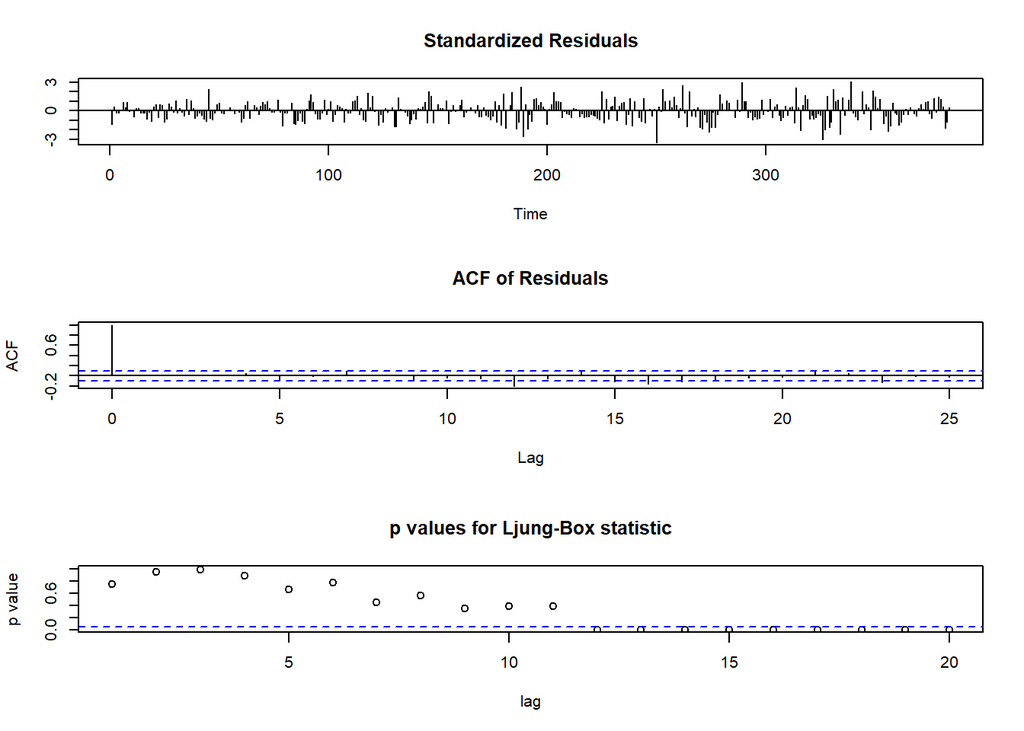

```r
# test the possible models of the residuals
tsdiag(NO.arima104, gof.lag = 20)
```

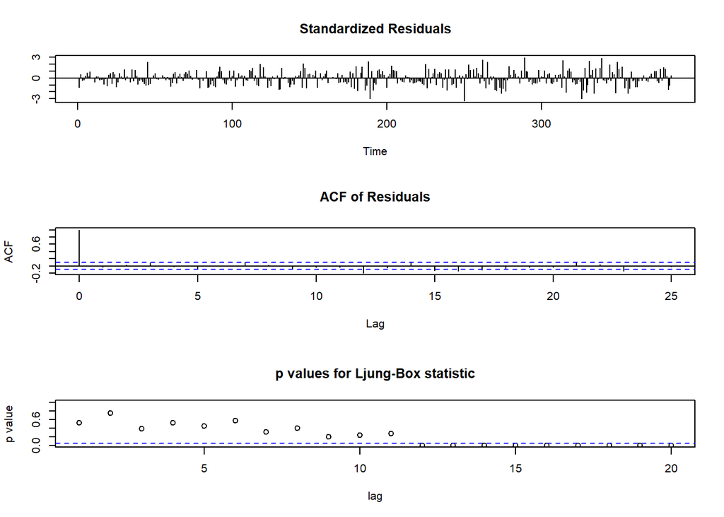

```r
tsdiag(NO.arima302, gof.lag = 20)
```

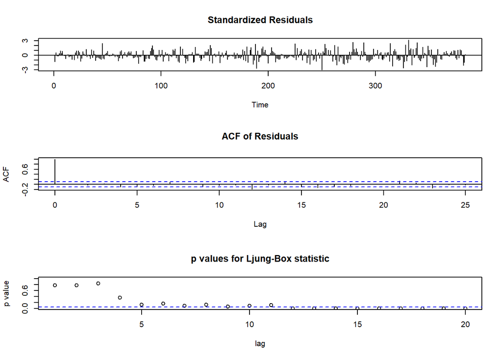

```r
tsdiag(NO.residuals.auto, gof.lag = 20)
```

### Choose Model for Residuals

```r
NO.residuals <- NO.arima104
```

This model has the lowest AIC and also the best diagnostic plot of the models considered.

## Final Model

The final model includes a trend and seasonality, using 9 different periods, two of which are the averages of 4 similar periods each. The ARIMA model of the residuals is a 1,0,4 model.

### Diagnostics

The residuals of the trend and seasonality linear model appear relatively normal, from the QQ plot. There are no points with high Cook’s distances. The residuals vs. fitted and scale-location plots have minor problems; they could have more even spread, but overall they look good and indicate acceptable fit. In the diagnostic plot for the model of the residuals, the p-value for the Ljung-Box stastic is above the dashed line for 11 of the 20 lags, meaning that the model of the residuals is adequate for up to 11 lags. A future model could work to extend the model adequacy to all 20 lags of the plot.

# Multivariate Time Series

## Seasonality and Trends

We used the same linear models for the seasonality and trends that we discovered in our analysis of the univariate time series for CO and NO2. See above for how we modeled seasonal components and trends to produce these linear models.  
The ARMA models for the residuals of both time series use d = 0, meaning that both meet the stationarity assumption without taking the first differences.

## Autoregressive and Moving Average Terms

In our univariate models, the residuals for CO were modeled with an ARIMA(2,0,1) model and the residuals for NO2 were modeled with an ARIMA(1,0,4) model. There were autoregressive and moving average terms in both cases. Since there were different p and q values used to model the residuals for each time series, it is difficult to use the ACF and PACF to determine values for p and q for the multivariate model. Because of this, we will test models with p from 1 to 2 and q from 0 to 4 to determine the best VARMA model.

## Models

```r
# all residuals together
allResiduals <- data.frame(CO.lm$residuals, NO.lm$residuals)

# Build VARMA models

# p from 1 to 2, q from 0 to 4
AICmatrix <- matrix(NA, 2, 5)
for(p in 1:2) {
  for(q in 0:4) {
    varma.model <- VARMACpp(allResiduals, p=p, q=q, include.mean=F)
    AICmatrix[p,q+1] <- varma.model$aic
  }
}
```

[output not shown]

[output cut: 171 more lines]

```
## [1,] -0.0273 -0.0031
## [2,]  0.9244  0.1464
##
## Residuals cov-matrix:
##          [,1]       [,2]
## [1,]  3.79553   16.46204
## [2,] 16.46204 1937.98629
## ----
## aic=  8.969858
## bic=  9.17562
## Number of parameters:  8
## initial estimates:  0.4577 -0.0024 -0.1069 0.0021 1.2773 0.3462 -2.0536 0.0295
## Par. lower-bounds:  0.3129 -0.0096 -0.2517 -0.0052 -1.6133 0.2011 -4.9436 -0.1159
## Par. upper-bounds:  0.6024 0.0049 0.0378 0.0094 4.1679 0.4914 0.8365 0.1749
## Final   Estimates:  0.4043058 0.004911762 -0.01397712 0.009378928 -0.02518505 0.2011209 0.004322574 0.09543027
```

[output not shown]

[output cut: 201 more lines]

```
##        [,1]     [,2]
## [1,] -0.016  0.00359
## [2,]  1.232 -0.04257
## MA( 4 )-matrix
##       [,1]    [,2]
## [1,] -0.21 0.01711
## [2,]  3.28 0.00694
##
## Residuals cov-matrix:
##            [,1]       [,2]
## [1,]   7.522355  -18.13386
## [2,] -18.133861 2188.45696
## ----
## aic=  9.813654
## bic=  10.06057
```

## Model Comparison

### Metrics

```r
# get AIC matrix
print('AIC Matrix')
```

```
## [1] "AIC Matrix"
```

```r
AICmatrix
```

```
##          [,1]     [,2]     [,3]     [,4]     [,5]
## [1,] 7.103681 7.779971 7.108223 7.130918 8.969858
## [2,] 7.314305 8.141910 7.098223 7.124299 9.813654
```

```r
# sort the matrix
AICmatrix.sorted <- sort(AICmatrix, decreasing = F, index.return = T)

# print the sorted matrix
print('sorted AIC matrix')
```

```
## [1] "sorted AIC matrix"
```

```r
AICmatrix.sorted
```

```
## $x
##  [1] 7.098223 7.103681 7.108223 7.124299 7.130918 7.314305 7.779971
##  [8] 8.141910 8.969858 9.813654
##
## $ix
##  [1]  6  1  5  8  7  2  3  4  9 10
```

The two models with the lowest AIC values are VARMA(2,2) and VARMA(1,0) with an AIC of 7.098223 and 7.103681, respectively.

## create the models

```r
# model with lowest AIC
varma.model1 <- VARMACpp(allResiduals, p=2, q=2, include.mean=F)
```

```
## Number of parameters:  16
## initial estimates:  0.8914 -0.0191 -0.4729 0.0071 12.5696 0.3034 -7.8712 0.1275 -0.475 0.0182 0.2559 0.0015 -12.293 0.0577 1.5119 -0.0824
## Par. lower-bounds:  0.3535 -0.0533 -0.8276 -0.0147 1.817 -0.3801 -14.9618 -0.3082 -1.0328 -0.0168 -0.0663 -0.016 -23.4419 -0.6422 -4.9289 -0.4325
## Par. upper-bounds:  1.4294 0.0151 -0.1181 0.0288 23.3222 0.9869 -0.7806 0.5632 0.0828 0.0532 0.5781 0.019 -1.144 0.7575 7.9526 0.2677
## Final   Estimates:  0.8914231 -0.01912298 -0.4728765 0.007050431 12.5696 0.3034098 -7.871199 0.1274901 -0.4749762 0.01821911 0.2558906 0.001505135 -12.29296 0.05765493 1.511878 -0.08240032
##
## Coefficient(s):
##                   Estimate  Std. Error  t value Pr(>|t|)
## CO.lm.residuals   0.891423          NA       NA       NA
## NO.lm.residuals  -0.019123          NA       NA       NA
## CO.lm.residuals  -0.472876          NA       NA       NA
## NO.lm.residuals   0.007050          NA       NA       NA
## CO.lm.residuals  12.569595          NA       NA       NA
## NO.lm.residuals   0.303410          NA       NA       NA
## CO.lm.residuals  -7.871199          NA       NA       NA
## NO.lm.residuals   0.127490          NA       NA       NA
##                  -0.474976          NA       NA       NA
##                   0.018219          NA       NA       NA
##                   0.255891          NA       NA       NA
##                   0.001505          NA       NA       NA
##                 -12.292959          NA       NA       NA
##                   0.057655          NA       NA       NA
##                   1.511878          NA       NA       NA
##                  -0.082400          NA       NA       NA
## ---
## Estimates in matrix form:
## AR coefficient matrix
## AR( 1 )-matrix
##        [,1]    [,2]
## [1,]  0.891 -0.0191
## [2,] 12.570  0.3034
## AR( 2 )-matrix
##        [,1]    [,2]
## [1,] -0.473 0.00705
## [2,] -7.871 0.12749
## MA coefficient matrix
## MA( 1 )-matrix
##        [,1]    [,2]
## [1,]  0.475 -0.0182
## [2,] 12.293 -0.0577
## MA( 2 )-matrix
##        [,1]     [,2]
## [1,] -0.256 -0.00151
## [2,] -1.512  0.08240
##
## Residuals cov-matrix:
##          [,1]      [,2]
## [1,]  2.38051  32.93033
## [2,] 32.93033 923.11764
## ----
## aic=  7.098223
## bic=  7.262833
```

```r
# model with second lowest AIC
varma.model2 <- VARMACpp(allResiduals, p=1, q=0, include.mean=F)
```

```
## Number of parameters:  4
## initial estimates:  0.4124 -0.0013 0.4313 0.3605
## Par. lower-bounds:  0.2788 -0.0081 -2.2295 0.2259
## Par. upper-bounds:  0.546 0.0055 3.0921 0.4951
## Final   Estimates:  0.3875942 0.005454857 -0.0007040024 0.3754043
##
## Coefficient(s):
##                  Estimate  Std. Error  t value Pr(>|t|)
## CO.lm.residuals  0.387594    0.059512    6.513 7.37e-11 ***
## NO.lm.residuals  0.005455    1.024478    0.005    0.996
## CO.lm.residuals -0.000704    0.003206   -0.220    0.826
## NO.lm.residuals  0.375404    0.059825    6.275 3.50e-10 ***
## ---
## Signif. codes:  0 '***' 0.001 '**' 0.01 '*' 0.05 '.' 0.1 ' ' 1
## ---
## Estimates in matrix form:
## AR coefficient matrix
## AR( 1 )-matrix
##           [,1]    [,2]
## [1,]  0.387594 0.00545
## [2,] -0.000704 0.37540
##
## Residuals cov-matrix:
##           [,1]     [,2]
## [1,]  2.464721  33.7206
## [2,] 33.720604 944.7054
## ----
## aic=  7.103681
## bic=  7.144833
```

### Diagnostics

```r
# diagnostics for model1
MTSdiag(varma.model1)
```

```
## [1] "Covariance matrix:"
##                 CO.lm.residuals NO.lm.residuals
## CO.lm.residuals            2.39              33
## NO.lm.residuals           33.02             926
## CCM at lag:  0
##       [,1]  [,2]
## [1,] 1.000 0.702
## [2,] 0.702 1.000
## Simplified matrix:
## CCM at lag:  1
## . .
## . .
## CCM at lag:  2
## . .
## . .
## CCM at lag:  3
## . .
## . .
## CCM at lag:  4
## . .
## . .
## CCM at lag:  5
## - .
## - .
## CCM at lag:  6
## . .
## . .
## CCM at lag:  7
## + .
## . .
## CCM at lag:  8
## . .
## . .
## CCM at lag:  9
## . .
## - .
## CCM at lag:  10
## . .
## . .
## CCM at lag:  11
```

[output cut: 26 more lines]

```
## CCM at lag:  20
## . .
## . .
## CCM at lag:  21
## + .
## + +
## CCM at lag:  22
## + .
## + .
## CCM at lag:  23
## - -
## . -
## CCM at lag:  24
## . .
## . .
```

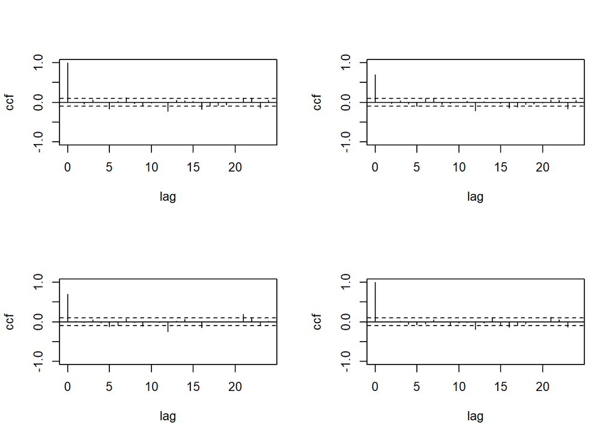

```
## Hit Enter for p-value plot of individual ccm:
```

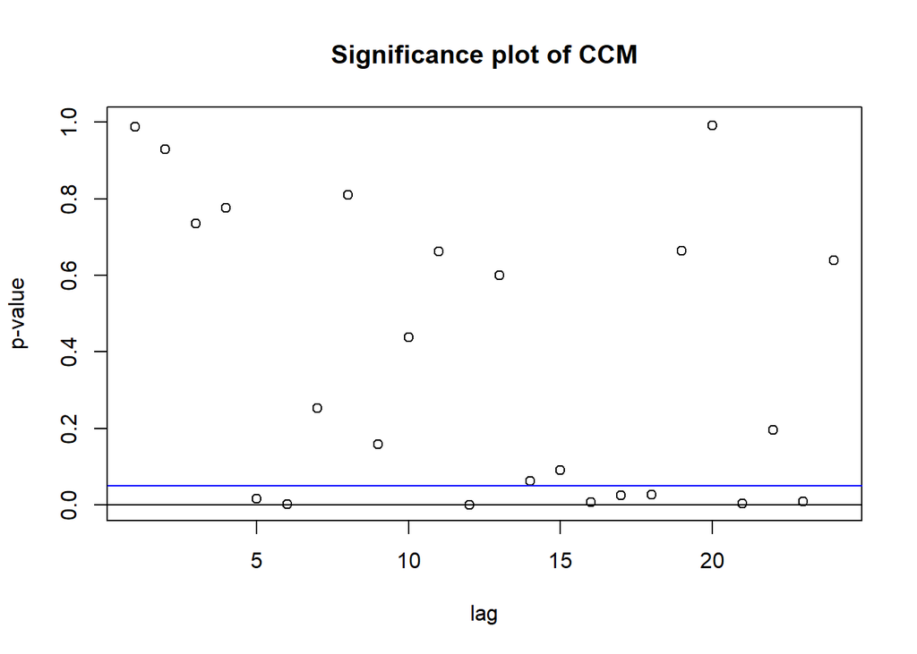

```
## Hit Enter to compute MQ-statistics:
##
## Ljung-Box Statistics:
##           m       Q(m)     df    p-value
##  [1,]   1.000     0.317   4.000     0.99
##  [2,]   2.000     1.192   8.000     1.00
##  [3,]   3.000     3.209  12.000     0.99
##  [4,]   4.000     4.997  16.000     1.00
##  [5,]   5.000    17.183  20.000     0.64
##  [6,]   6.000    34.623  24.000     0.07
##  [7,]   7.000    40.010  28.000     0.07
##  [8,]   8.000    41.613  32.000     0.12
##  [9,]   9.000    48.265  36.000     0.08
## [10,]  10.000    52.054  40.000     0.10
## [11,]  11.000    54.469  44.000     0.13
## [12,]  12.000    83.534  48.000     0.00
## [13,]  13.000    86.300  52.000     0.00
## [14,]  14.000    95.297  56.000     0.00
## [15,]  15.000   103.338  60.000     0.00
## [16,]  16.000   117.516  64.000     0.00
## [17,]  17.000   128.654  68.000     0.00
## [18,]  18.000   139.678  72.000     0.00
## [19,]  19.000   142.081  76.000     0.00
## [20,]  20.000   142.337  80.000     0.00
## [21,]  21.000   158.142  84.000     0.00
## [22,]  22.000   164.210  88.000     0.00
## [23,]  23.000   177.591  92.000     0.00
## [24,]  24.000   180.135  96.000     0.00
```

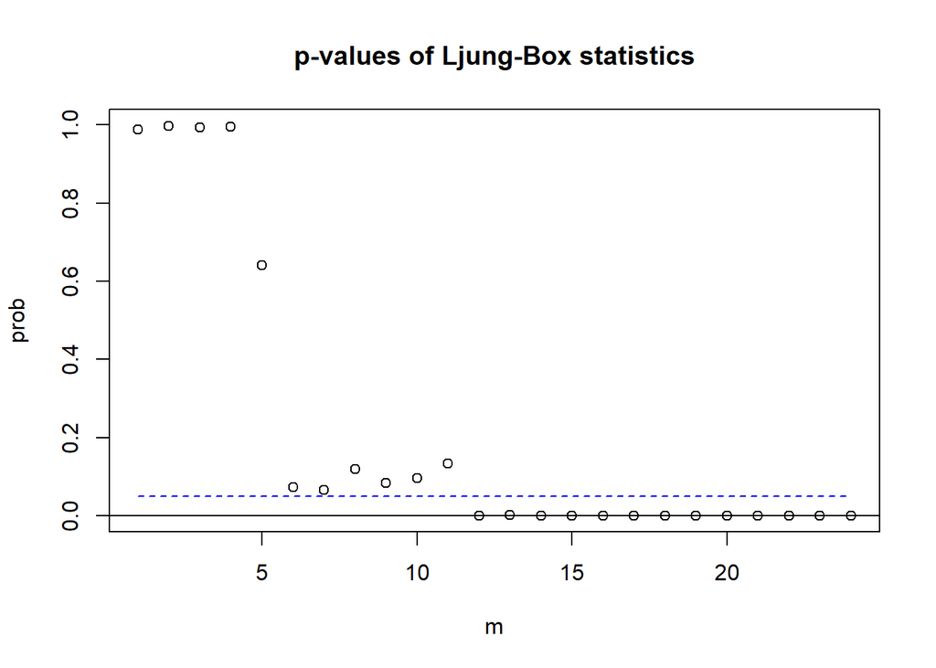

```
## Hit Enter to obtain residual plots:
```

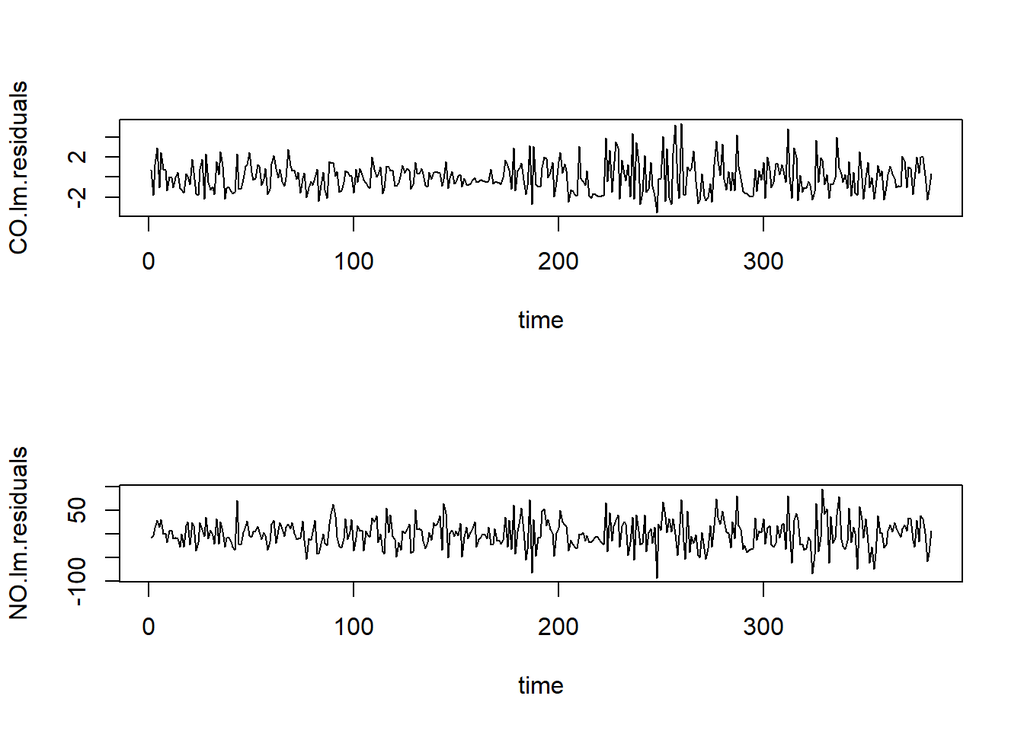

```r
# diagnostics for model2
MTSdiag(varma.model2)
```

```
## [1] "Covariance matrix:"
##                 CO.lm.residuals NO.lm.residuals
## CO.lm.residuals            2.47            33.8
## NO.lm.residuals           33.81           947.2
## CCM at lag:  0
##       [,1]  [,2]
## [1,] 1.000 0.699
## [2,] 0.699 1.000
## Simplified matrix:
## CCM at lag:  1
## . -
## . .
## CCM at lag:  2
## . .
## . .
## CCM at lag:  3
## . .
## . .
## CCM at lag:  4
## . -
## . .
## CCM at lag:  5
## - -
## - -
## CCM at lag:  6
## . +
## . .
## CCM at lag:  7
## + +
## + .
## CCM at lag:  8
## . .
## . .
## CCM at lag:  9
## . .
## . .
## CCM at lag:  10
## . .
## . .
## CCM at lag:  11
```

[output cut: 26 more lines]

```
## CCM at lag:  20
## . .
## . .
## CCM at lag:  21
## + .
## + +
## CCM at lag:  22
## + .
## + .
## CCM at lag:  23
## - -
## . -
## CCM at lag:  24
## . .
## . .
```

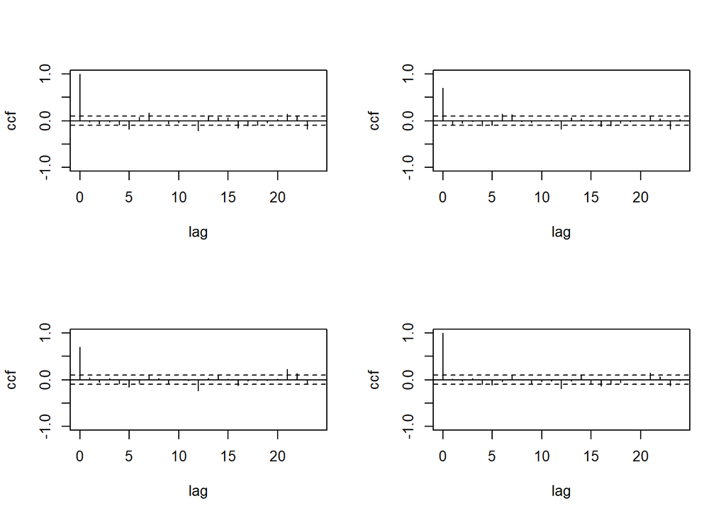

```
## Hit Enter for p-value plot of individual ccm:
```

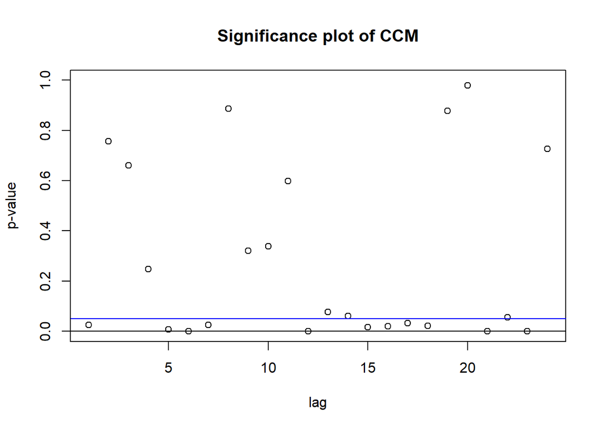

```
## Hit Enter to compute MQ-statistics:
##
## Ljung-Box Statistics:
##         m       Q(m)     df    p-value
##  [1,]   1.0      11.2     4.0     0.02
##  [2,]   2.0      13.1     8.0     0.11
##  [3,]   3.0      15.5    12.0     0.21
##  [4,]   4.0      20.9    16.0     0.18
##  [5,]   5.0      34.8    20.0     0.02
##  [6,]   6.0      58.7    24.0     0.00
##  [7,]   7.0      69.8    28.0     0.00
##  [8,]   8.0      71.0    32.0     0.00
##  [9,]   9.0      75.7    36.0     0.00
## [10,]  10.0      80.2    40.0     0.00
## [11,]  11.0      83.0    44.0     0.00
## [12,]  12.0     107.3    48.0     0.00
## [13,]  13.0     115.8    52.0     0.00
## [14,]  14.0     124.8    56.0     0.00
## [15,]  15.0     136.9    60.0     0.00
## [16,]  16.0     148.8    64.0     0.00
## [17,]  17.0     159.3    68.0     0.00
## [18,]  18.0     170.9    72.0     0.00
## [19,]  19.0     172.1    76.0     0.00
## [20,]  20.0     172.5    80.0     0.00
## [21,]  21.0     192.7    84.0     0.00
## [22,]  22.0     202.0    88.0     0.00
## [23,]  23.0     220.3    92.0     0.00
## [24,]  24.0     222.4    96.0     0.00
```

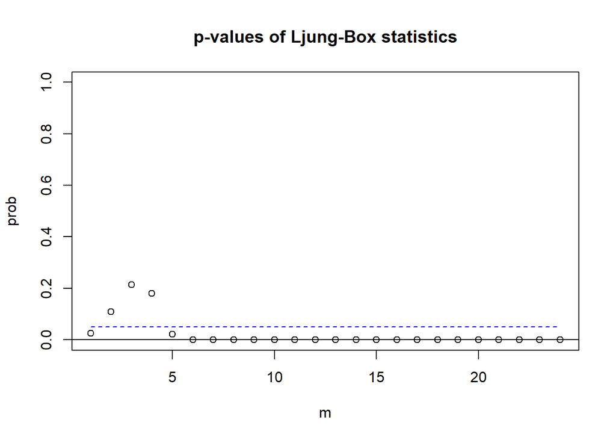

```
## Hit Enter to obtain residual plots:
```

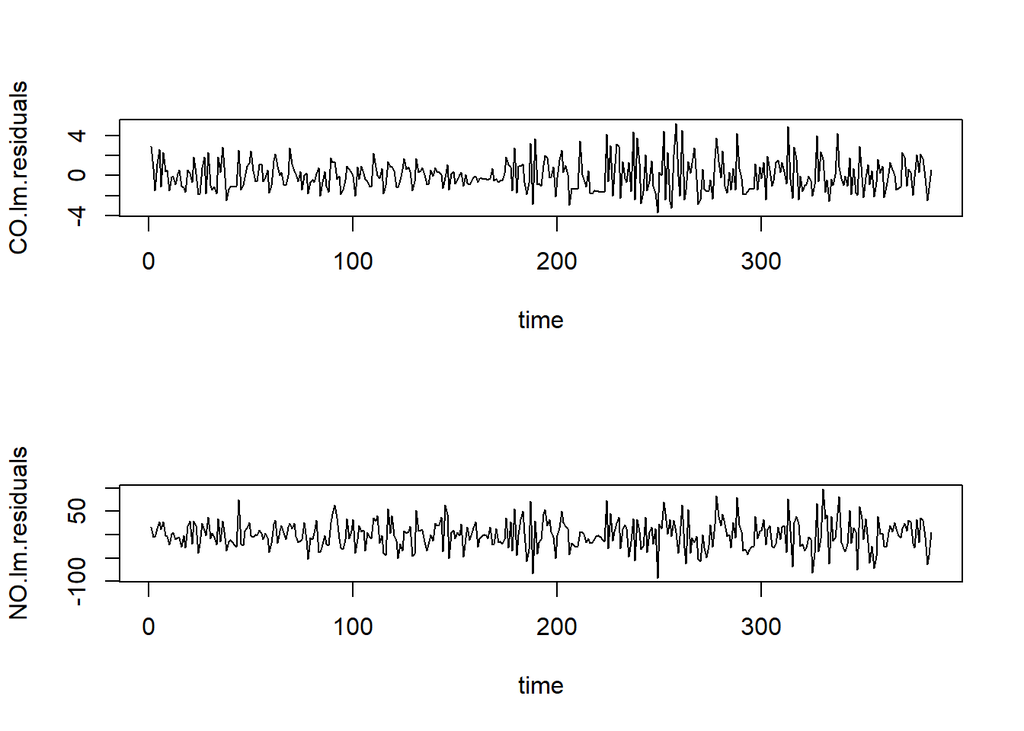

The VARMA(2,2) model performs best in the diagnostics. The model is adequate for 11 lags, as the p-values for the Ljung-Box statistic are above the dashed line for these points. The second model we tested had three Ljung-Box statistics at lags 2, 3, and 4 with a p-value above the dashed line.

## Final Model

We did not include the chunk that actually ran the code to create the final model, so that it would not print the output. The commented code below is the code we ran.

```r
# varma.model <- VARMACpp(allResiduals, p=2, q=2, include.mean=F)
```

The final model was chosen as the VARMA(2,2) model, because it has the lowest AIC and performed the best in the diagnostic plot.

### Diagnostics

The model is adequate for up to 11 lags, based on the diagnostic plot. Future work could attempt to produce a model adequate for more lags, but we feel that this is acceptable performance from the model we have chosen.

# Simulation from Univariate CO Model

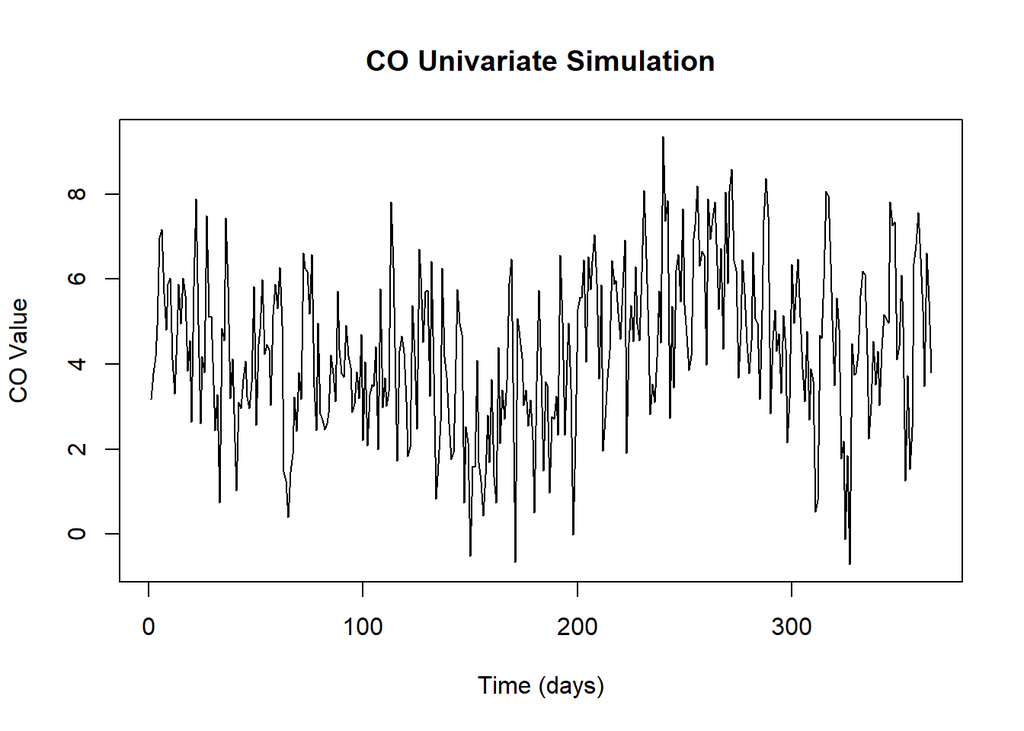

```r
# CO ARIMA model is 2,0,1

# simulate residuals
# set the seed
set.seed(1)

# choose time duration for simulation
## 365 was choosen because we are modeling a year
n = 365

CO.uni.sim <- arima.sim(n = n, list(ar = c(CO.residuals$coef[1],
                                             CO.residuals$coef[2]),
                                      ma = c(CO.residuals$coef[3])),
                                      sd = sqrt(CO.residuals$sigma2))

# the next time variable- simulate the next 365 days
next.time.time <- c(1:(n))
next.time <- data.frame(time.CO = next.time.time)

CO.mean <- predict(CO.lm, newdata = next.time)

# make time series
CO.uni.sim.ts <- ts(CO.uni.sim + CO.mean)

plot(CO.uni.sim + CO.mean, main = "CO Univariate Simulation", ylab="CO Value", xlab="Time (days)")
```

This is the plot of the simulation.

## Visualization

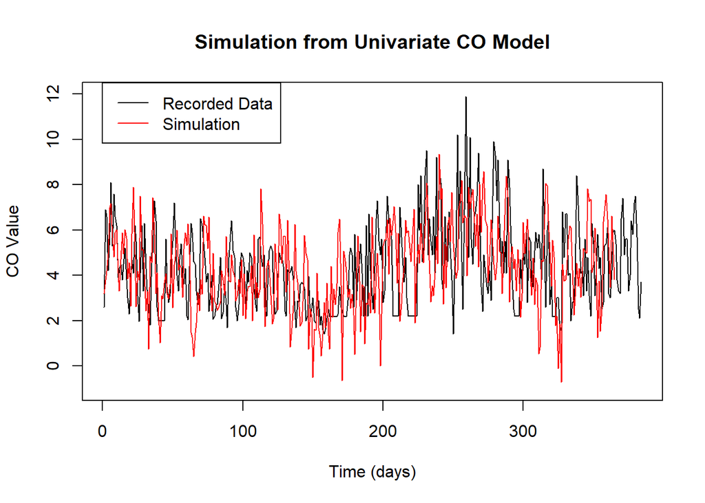

```r
# plot simulated values with observations
plot(CO.ts, main = "Simulation from Univariate CO Model", col = "black", ylim = c(-1,12), ylab="CO Value", xlab="Time (days)")
lines(CO.uni.sim.ts, col = "red")
legend(0, 12.5, legend = c("Recorded Data", "Simulation"), col = c("black", "red"), lwd = 1)
```

The simulation values appear to be similar to the time series data, though they are slightly larger than the time series before t = 200.

## Trend

```r
# linear model for simulation
CO.sim.lm <- lm(CO.uni.sim.ts ~ next.time.time)
summary(CO.sim.lm)
```

```
##
## Call:
## lm(formula = CO.uni.sim.ts ~ next.time.time)
##
## Residuals:
##    Min     1Q Median     3Q    Max
## -5.513 -1.171  0.006  1.368  4.819
##
## Coefficients:
##                 Estimate Std. Error t value Pr(>|t|)
## (Intercept)    3.7706155  0.1933586  19.501  < 2e-16 ***
## next.time.time 0.0031546  0.0009157   3.445 0.000638 ***
## ---
## Signif. codes:  0 '***' 0.001 '**' 0.01 '*' 0.05 '.' 0.1 ' ' 1
##
## Residual standard error: 1.843 on 363 degrees of freedom
## Multiple R-squared:  0.03166,    Adjusted R-squared:  0.02899
## F-statistic: 11.87 on 1 and 363 DF,  p-value: 0.0006376
```

```r
summary(CO.lm.trend)
```

```
##
## Call:
## lm(formula = CO.ts ~ time.CO)
##
## Residuals:
##     Min      1Q  Median      3Q     Max
## -3.2485 -1.6980 -0.0525  1.0863  7.3442
##
## Coefficients:
##             Estimate Std. Error t value Pr(>|t|)
## (Intercept) 3.810929   0.192140  19.834  < 2e-16 ***
## time.CO     0.002876   0.000865   3.325  0.00097 ***
## ---
## Signif. codes:  0 '***' 0.001 '**' 0.01 '*' 0.05 '.' 0.1 ' ' 1
##
## Residual standard error: 1.879 on 382 degrees of freedom
## Multiple R-squared:  0.02813,    Adjusted R-squared:  0.02558
## F-statistic: 11.06 on 1 and 382 DF,  p-value: 0.0009695
```

We made a linear model for the simulation with time as a predictor to determine if there was a trend to the data. The model was significant, meaning that there is a trend to the simulation. The estimated coefficient value was 0.0032 for the simulation and 0.0029 for the original time series. These coefficients are very close, so the simulation was able to accurately reproduce the trend of the original time series.

## Seasonality

```r
# compare periodogram of observations and periodogram of simulation
par(mfrow = c(1,2))
pg.CO <- spec.pgram(CO.ts,spans=9,demean=T,log='no', main="Collected Data Periodogram")
pg.CO.uni.sim <- spec.pgram(CO.uni.sim.ts, spans = 9, demean = T, log = 'no', main="Simulation Periodogram")
```

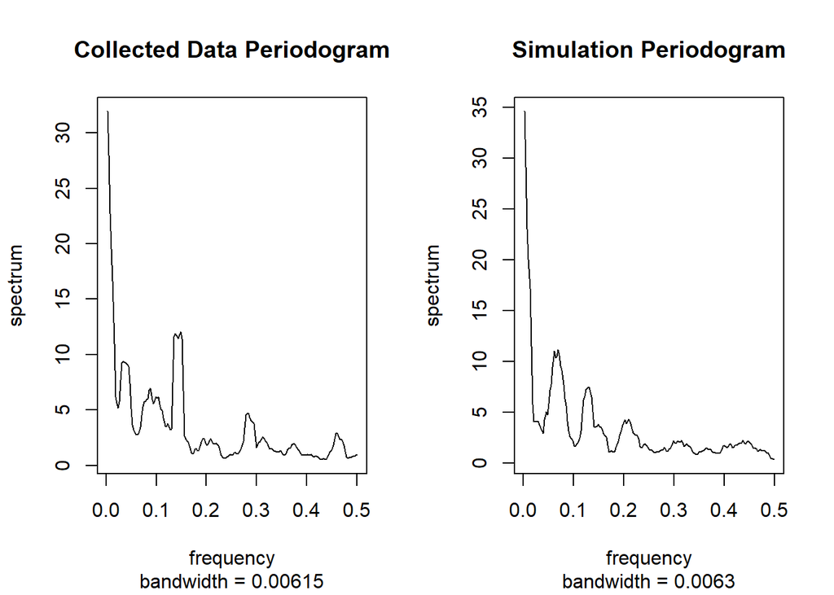

```r
par(mfrow = c(1,1))
```

The periodograms of the original observations and simulation look similar. They have similar peak locations and magnitudes, especially at the lower end of the frequencies. The simulation was able to closely reproduce the seasonality of the time series.

## Mean and Variance

```r
# mean of observations
mean(CO.ts)
```

```
## [1] 4.364574
```

```r
# mean of simulation
mean(CO.uni.sim.ts)
```

```
## [1] 4.347904
```

```r
# variance of observations
var(CO.ts)
```

```
## [1] 3.622965
```

```r
# variance of simulation
var(CO.uni.sim.ts)
```

```
## [1] 3.499064
```

The mean of the original time series is 4.36, and the mean of the simulation is 4.34. The means are very close together, which was apparent from the plot of both the time series and simulation together.  
The variance of the original time series is 3.62, and the variance of the simulation is 3.499. The variances are also similar.

## Auto-Correlation

```r
# ACF of observations
acf(CO.ts)
```

[output not shown]

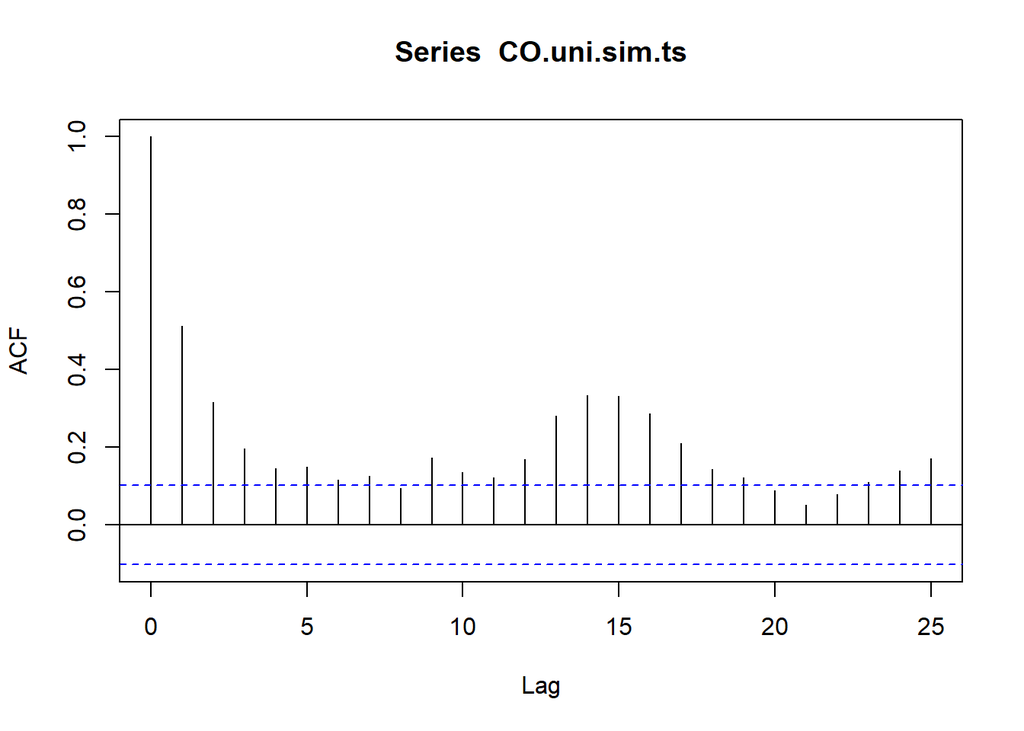

```r
# ACF of simulation
acf(CO.uni.sim.ts)
```

The simulation got close to reproducing the ACF of the time series. They both cutoff and become significant again and show somewhat sinusoidal behavior.

```r
# PACF of observations
pacf(CO.ts)
```

[output not shown]

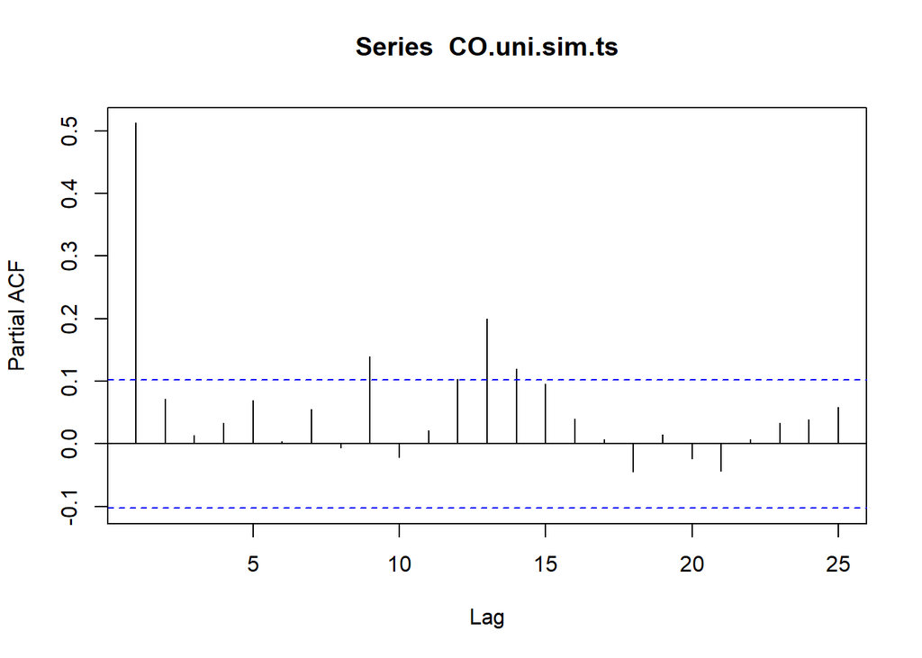

```r
# PACF of simulation
pacf(CO.uni.sim.ts)
```

The ACFs look more similar, though the PACF of the time series and simulation are close as well. Both cutoff and become significant again, and both are significant for the first lag but not for the second.

From comparing the ACF and PACF of the time series and simulation, the simulation was able to reproduce the autocorrelation of the time series.

# Simulation from Univariate NO2 Model

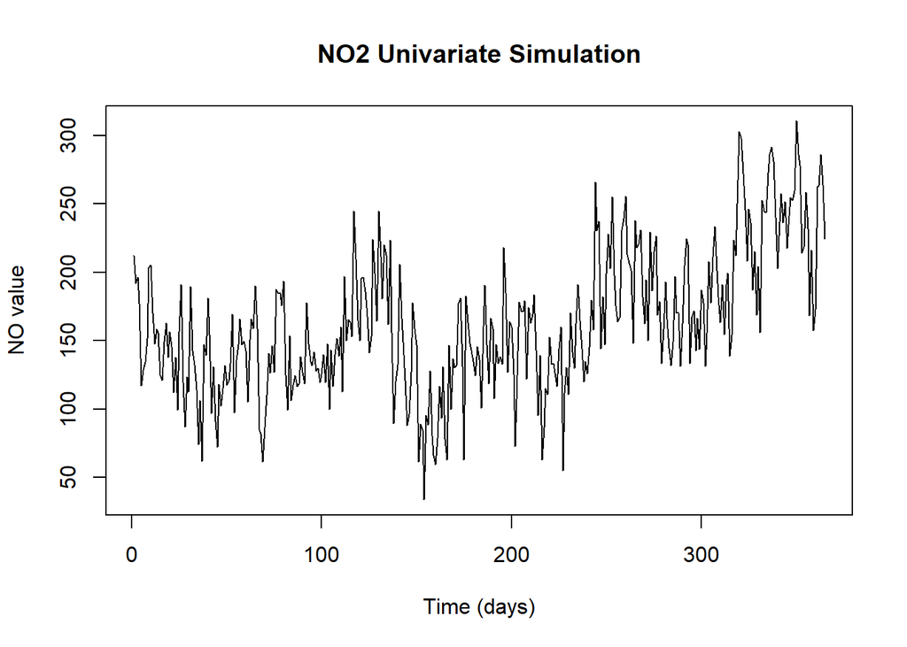

```r
# NO2 ARIMA model is 1,0,4

# simulate residuals
# set the seed
set.seed(1)

# choose time duration for simulation
n = 365

# simulation
NO.uni.sim <- arima.sim(n = n, list(ar = c(NO.residuals$coef[1]),
                                      ma = c(NO.residuals$coef[2],
                                             NO.residuals$coef[3],
                                             NO.residuals$coef[4],
                                             NO.residuals$coef[5])),
                                      sd = sqrt(NO.residuals$sigma2))

# the next time variable- simulate the next 365 days
next.time.NO <- data.frame(time.NO = next.time.time)

NO.mean <- predict(NO.lm, newdata = next.time.NO)

# make time series
NO.uni.sim.ts <- ts(NO.uni.sim + NO.mean)

plot(NO.uni.sim + NO.mean, main = "NO2 Univariate Simulation", ylab="NO value", xlab="Time (days)")
```

This is the plot of the simulation.

## Visualization

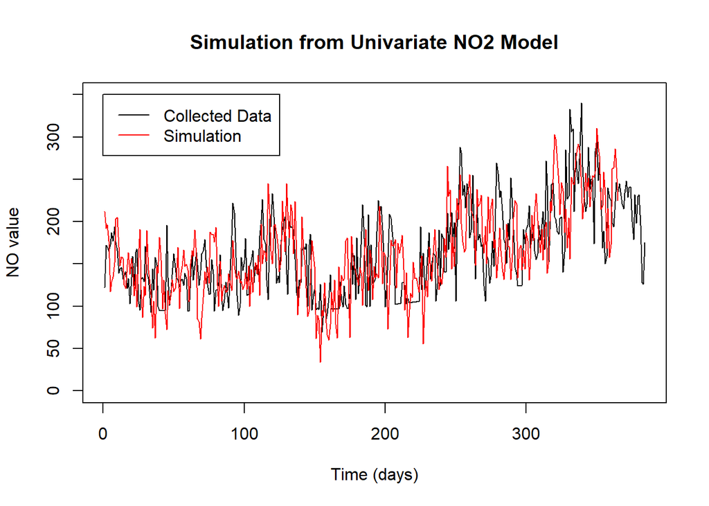

```r
# plot simulated values with observations
plot(NO.ts, main = "Simulation from Univariate NO2 Model", col = "black", ylim = c(0,350), ylab="NO value", xlab="Time (days)")
lines(NO.uni.sim.ts, col = "red")
legend(0, 350, legend = c("Collected Data", "Simulation"), col = c("black", "red"), lwd = 1)
```

The simulation values appear similar to the time series values, especially in the trend of the data.

## Trend

```r
# linear model for simulation
NO.sim.lm <- lm(NO.uni.sim.ts ~ next.time.time)
summary(NO.sim.lm)
```

```
##
## Call:
## lm(formula = NO.uni.sim.ts ~ next.time.time)
##
## Residuals:
##      Min       1Q   Median       3Q      Max
## -121.395  -29.517    0.047   29.131  104.051
##
## Coefficients:
##                 Estimate Std. Error t value Pr(>|t|)
## (Intercept)    114.75310    4.52157   25.38   <2e-16 ***
## next.time.time   0.26246    0.02141   12.26   <2e-16 ***
## ---
## Signif. codes:  0 '***' 0.001 '**' 0.01 '*' 0.05 '.' 0.1 ' ' 1
##
## Residual standard error: 43.1 on 363 degrees of freedom
## Multiple R-squared:  0.2927, Adjusted R-squared:  0.2908
## F-statistic: 150.2 on 1 and 363 DF,  p-value: < 2.2e-16
```

```r
summary(NO.lm.trend)
```

```
##
## Call:
## lm(formula = NO.ts ~ time.NO)
##
## Residuals:
##     Min      1Q  Median      3Q     Max
## -87.389 -34.365   2.159  27.847 137.895
##
## Coefficients:
##              Estimate Std. Error t value Pr(>|t|)
## (Intercept) 115.16473    4.40111   26.17   <2e-16 ***
## time.NO       0.25646    0.01981   12.94   <2e-16 ***
## ---
## Signif. codes:  0 '***' 0.001 '**' 0.01 '*' 0.05 '.' 0.1 ' ' 1
##
## Residual standard error: 43.04 on 382 degrees of freedom
## Multiple R-squared:  0.3049, Adjusted R-squared:  0.3031
## F-statistic: 167.6 on 1 and 382 DF,  p-value: < 2.2e-16
```

We made a linear model for the simulation with time as a predictor to determine if there was a trend to the data. The model was significant, meaning that there is a trend to the simulation. The estimated coefficient value was 0.262 for the simulation and 0.256 for the original time series. These coefficients are very close, so the simulation was able to accurately reproduce the trend of the original time series.

## Seasonality

```r
# compare periodogram of observations and periodogram of simulation
par(mfrow = c(1,2))
pg.NO <- spec.pgram(NO.ts,spans=9, demean=T, log='no', main="Collected NO Data Periodogram")
pg.NO.uni.sim <- spec.pgram(NO.uni.sim.ts, spans = 9, demean = T, log = 'no', main="Simulated NO Periodogram")
```

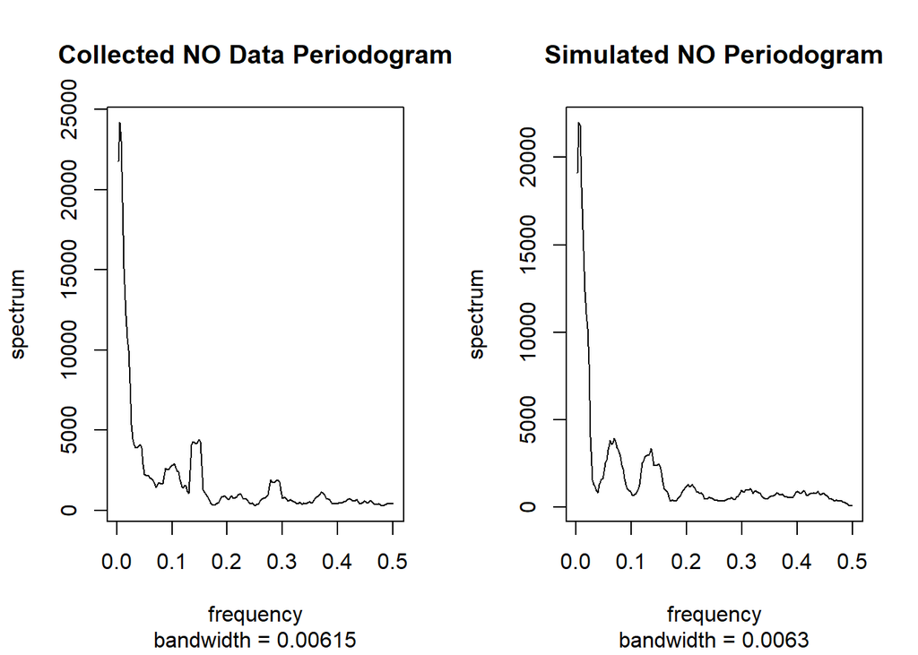

```r
par(mfrow = c(1,1))
```

The periodograms of the original observations and simulation look similar, but the periodogram for the simulation appears to have different peaks in the frequency range of 0.05 to 0.2. The simulation was able to somewhat closely reproduce the seasonality of the time series.

## Mean and Variance

```r
# mean of observations
mean(NO.ts)
```

```
## [1] 164.5335
```

```r
# mean of simulation
mean(NO.uni.sim.ts)
```

```
## [1] 162.7834
```

```r
# variance of observations
var(NO.ts)
```

```
## [1] 2657.722
```

```r
# variance of simulation
var(NO.uni.sim.ts)
```

```
## [1] 2619.679
```

The mean of the original time series is 164.53, and the mean of the simulation is 162.78. The means are very close together, which was apparent from the plot of both the time series and simulation together.  
The variance of the original time series is 2657.722, and the variance of the simulation is 2619.679. The variances are also similar, with the simulation being a little lower.

## Auto-Correlation

```r
# ACF of observations
acf(NO.ts)
```

[output not shown]

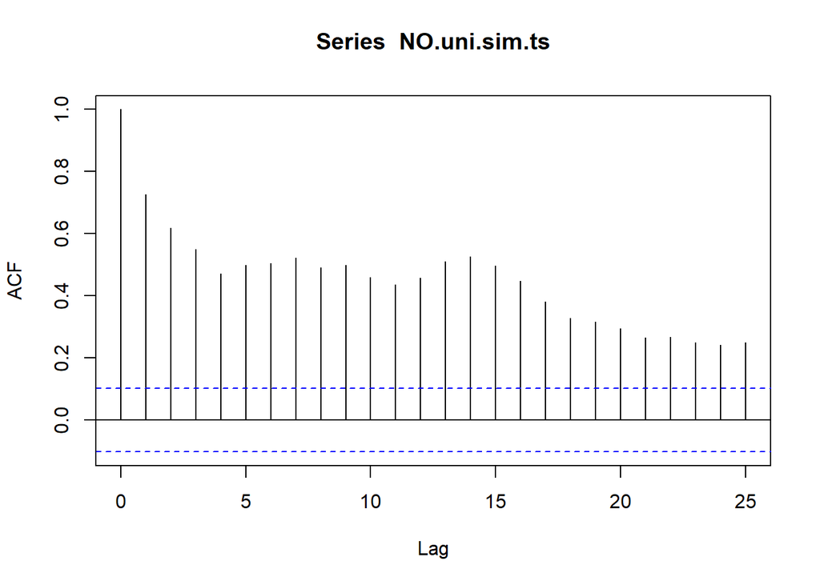

```r
# ACF of simulation
acf(NO.uni.sim.ts)
```

The ACFs look very similar; they are both significant for all 25 lags in view on the plot and have some sinusoidal behavior.

```r
# PACF of observations
pacf(CO.ts)
```

[output not shown]

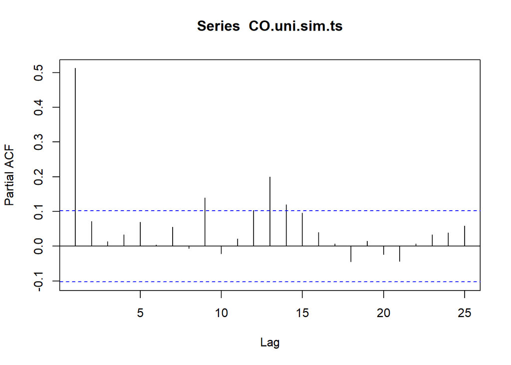

```r
# PACF of simulation
pacf(CO.uni.sim.ts)
```

# Simulation from Multivariate Model

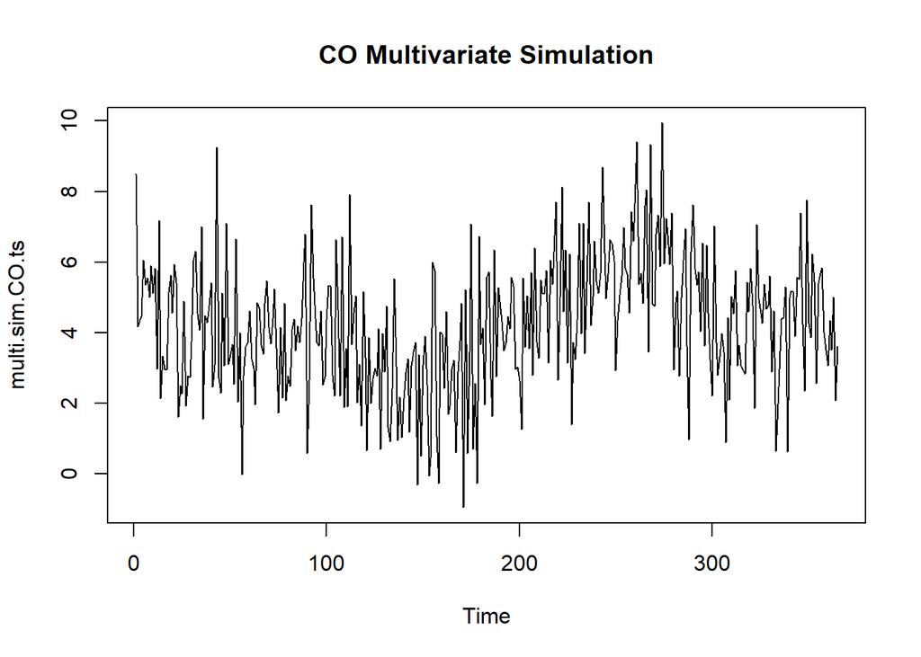

```r
# VARMA model is 2,2

# simulate residuals
# set the seed
set.seed(1)

# choose duration of simulation
n= 365

multi.sim <- VARMAsim(n=n, phi = varma.model$Phi,
                           theta = varma.model$Theta,
                           sigma = varma.model$Sigma)

# make time series
multi.sim.CO.ts <- ts(multi.sim$series[,1] + CO.mean)
multi.sim.NO.ts <- ts(multi.sim$series[,2] + NO.mean)
plot(multi.sim.CO.ts, main = "CO Multivariate Simulation")
```

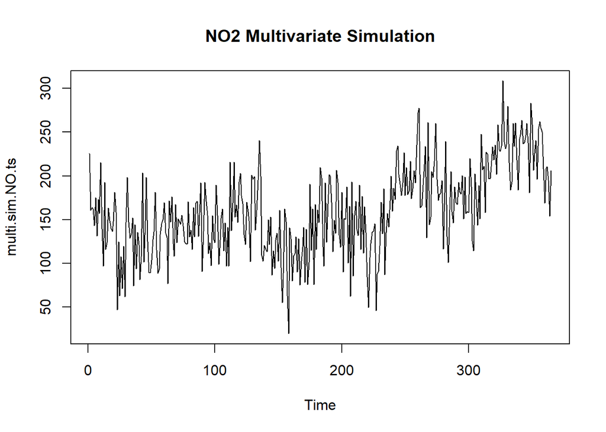

```r
plot(multi.sim.NO.ts, main = "NO2 Multivariate Simulation")
```

These are the plots of the simulations.

## Visualization- CO

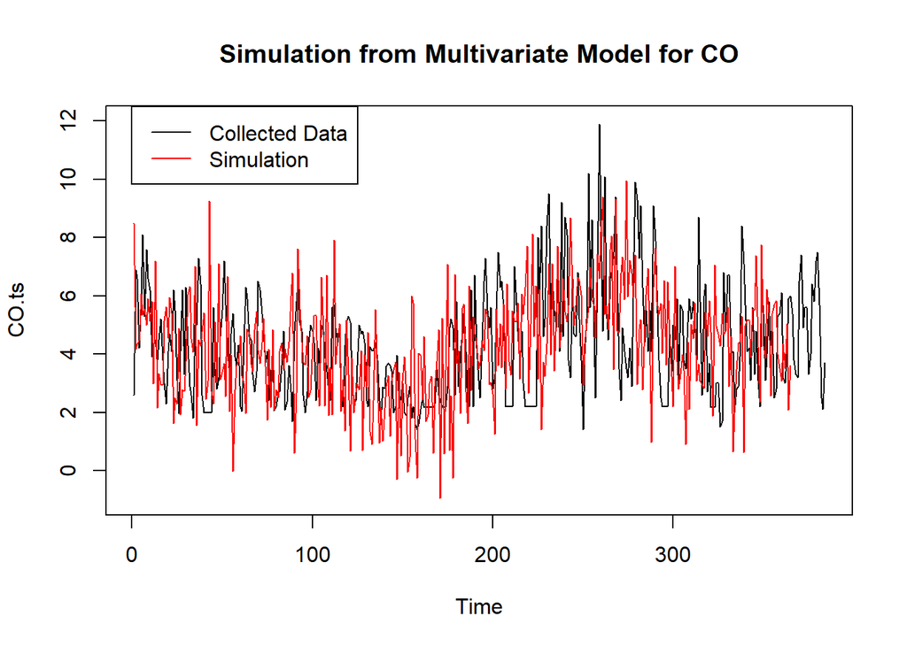

```r
# plot simulated values with observations
plot(CO.ts, main = "Simulation from Multivariate Model for CO", col = "black", ylim = c(-1,12))
lines(multi.sim.CO.ts, col = "red")
legend(0, 12.5, legend = c("Collected Data", "Simulation"), col = c("black", "red"), lwd = 1)
```

The simulation values appear to be similar to the time series data.

## Visualization- NO2

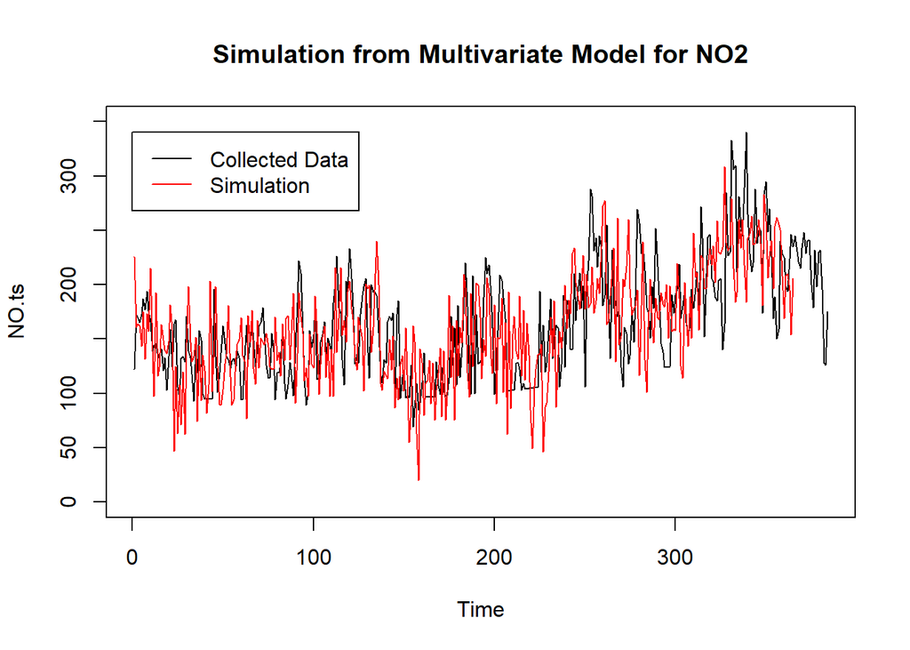

```r
# plot simulated values with observations
plot(NO.ts, main = "Simulation from Multivariate Model for NO2", col = "black", ylim = c(0,350))
lines(multi.sim.NO.ts, col = "red")
legend(0, 340, legend = c("Collected Data", "Simulation"), col = c("black", "red"), lwd = 1)
```

The simulation values appear to be similar to the time series data.

## Trend- CO

```r
# linear model for simulation
CO.multi.sim.lm <- lm(multi.sim.CO.ts ~ next.time.time)
summary(CO.multi.sim.lm)
```

```
##
## Call:
## lm(formula = multi.sim.CO.ts ~ next.time.time)
##
## Residuals:
##     Min      1Q  Median      3Q     Max
## -5.1458 -1.2297 -0.0621  1.2077  5.4711
##
## Coefficients:
##                 Estimate Std. Error t value Pr(>|t|)
## (Intercept)    3.6405403  0.1957349  18.599  < 2e-16 ***
## next.time.time 0.0032704  0.0009269   3.528 0.000472 ***
## ---
## Signif. codes:  0 '***' 0.001 '**' 0.01 '*' 0.05 '.' 0.1 ' ' 1
##
## Residual standard error: 1.866 on 363 degrees of freedom
## Multiple R-squared:  0.03316,    Adjusted R-squared:  0.03049
## F-statistic: 12.45 on 1 and 363 DF,  p-value: 0.0004721
```

```r
summary(CO.lm.trend)
```

```
##
## Call:
## lm(formula = CO.ts ~ time.CO)
##
## Residuals:
##     Min      1Q  Median      3Q     Max
## -3.2485 -1.6980 -0.0525  1.0863  7.3442
##
## Coefficients:
##             Estimate Std. Error t value Pr(>|t|)
## (Intercept) 3.810929   0.192140  19.834  < 2e-16 ***
## time.CO     0.002876   0.000865   3.325  0.00097 ***
## ---
## Signif. codes:  0 '***' 0.001 '**' 0.01 '*' 0.05 '.' 0.1 ' ' 1
##
## Residual standard error: 1.879 on 382 degrees of freedom
## Multiple R-squared:  0.02813,    Adjusted R-squared:  0.02558
## F-statistic: 11.06 on 1 and 382 DF,  p-value: 0.0009695
```

We made a linear model for the simulation with time as a predictor to determine if there was a trend to the data. The model was significant, meaning that there is a trend to the simulation. The estimated coefficient value was 0.0033 for the simulation and 0.0029 for the original time series. These coefficients are very close, so the simulation was able to accurately reproduce the trend of the original time series.

## Trend- NO2

```r
# linear model for simulation
NO.multi.sim.lm <- lm(multi.sim.NO.ts ~ next.time.time)
summary(NO.multi.sim.lm)
```

```
##
## Call:
## lm(formula = multi.sim.NO.ts ~ next.time.time)
##
## Residuals:
##      Min       1Q   Median       3Q      Max
## -134.501  -29.136    2.347   30.415  111.289
##
## Coefficients:
##                 Estimate Std. Error t value Pr(>|t|)
## (Intercept)    113.98562    4.42632   25.75   <2e-16 ***
## next.time.time   0.25496    0.02096   12.16   <2e-16 ***
## ---
## Signif. codes:  0 '***' 0.001 '**' 0.01 '*' 0.05 '.' 0.1 ' ' 1
##
## Residual standard error: 42.2 on 363 degrees of freedom
## Multiple R-squared:  0.2896, Adjusted R-squared:  0.2876
## F-statistic:   148 on 1 and 363 DF,  p-value: < 2.2e-16
```

```r
summary(NO.lm.trend)
```

```
##
## Call:
## lm(formula = NO.ts ~ time.NO)
##
## Residuals:
##     Min      1Q  Median      3Q     Max
## -87.389 -34.365   2.159  27.847 137.895
##
## Coefficients:
##              Estimate Std. Error t value Pr(>|t|)
## (Intercept) 115.16473    4.40111   26.17   <2e-16 ***
## time.NO       0.25646    0.01981   12.94   <2e-16 ***
## ---
## Signif. codes:  0 '***' 0.001 '**' 0.01 '*' 0.05 '.' 0.1 ' ' 1
##
## Residual standard error: 43.04 on 382 degrees of freedom
## Multiple R-squared:  0.3049, Adjusted R-squared:  0.3031
## F-statistic: 167.6 on 1 and 382 DF,  p-value: < 2.2e-16
```

We made a linear model for the simulation with time as a predictor to determine if there was a trend to the data. The model was significant, meaning that there is a trend to the simulation. The estimated coefficient value was 0.255 for the simulation and 0.256 for the original time series. These coefficients are very close, so the simulation was able to accurately reproduce the trend of the original time series.

## Seasonality- CO

```r
# compare periodogram of observations and periodogram of simulation
par(mfrow = c(1,2))
pg.CO <- spec.pgram(CO.ts,spans=9,demean=T,log='no')
pg.CO.multi.sim <- spec.pgram(multi.sim.CO.ts, spans = 9, demean = T, log = 'no')
```

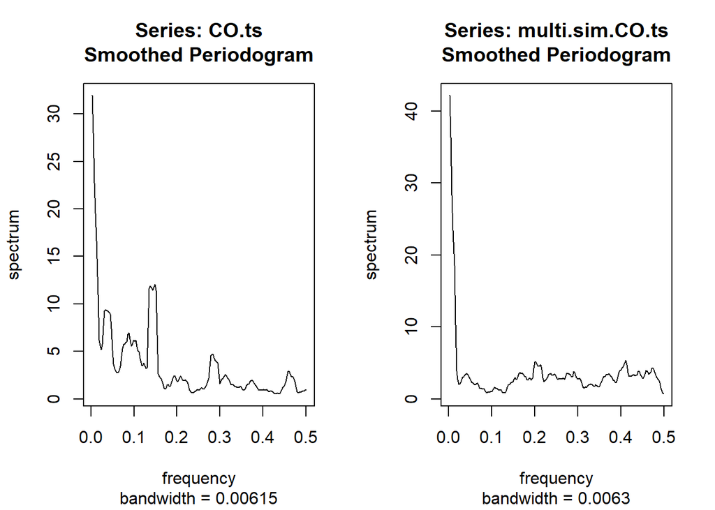

```r
par(mfrow = c(1,1))
```

The periodograms of the original observations and simulation are not very similar. There are fewer peaks in the simulation periodogram.

## Seasonality- NO2

```r
# compare periodogram of observations and periodogram of simulation
par(mfrow = c(1,2))
pg.NO <- spec.pgram(NO.ts,spans=9,demean=T,log='no')
pg.NO.multi.sim <- spec.pgram(multi.sim.NO.ts, spans = 9, demean = T, log = 'no')
```

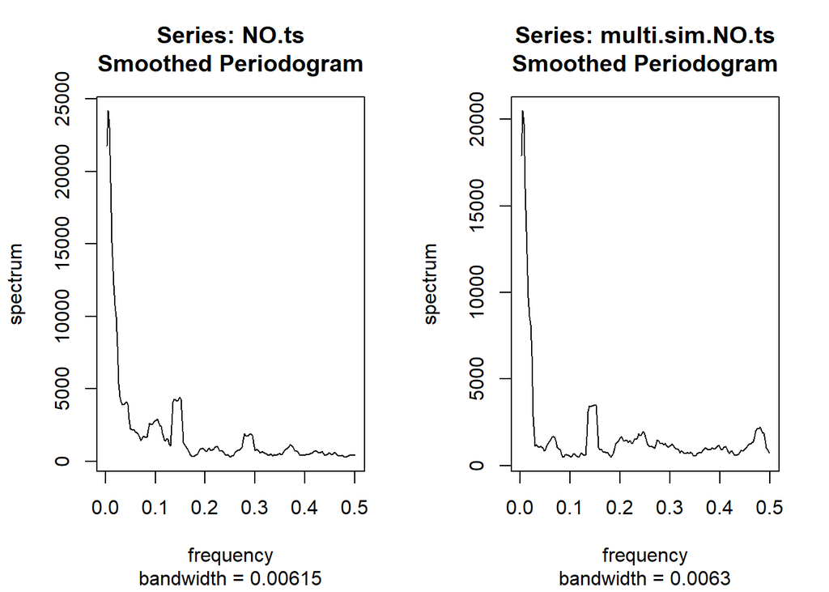

```r
par(mfrow = c(1,1))
```

The periodograms of the original observations and simulation are similar. There are similar peaks in similar locations in both periodograms.

## Mean and Variance

```r
# mean of observations- CO
mean(CO.ts)
```

```
## [1] 4.364574
```

```r
# mean of simulation- CO
mean(multi.sim.CO.ts)
```

```
## [1] 4.239021
```

```r
# mean of observations- NO2
mean(NO.ts)
```

```
## [1] 164.5335
```

```r
# mean of simulation- NO2
mean(multi.sim.NO.ts)
```

```
## [1] 160.6439
```

```r
# variance of observations- CO
var(CO.ts)
```

```
## [1] 3.622965
```

```r
# variance of simulation- CO
var(multi.sim.CO.ts)
```

```
## [1] 3.59114
```

```r
# variance of observations- NO2
var(NO.ts)
```

```
## [1] 2657.722
```

```r
# variance of simulation- NO2
var(multi.sim.NO.ts)
```

```
## [1] 2499.248
```

**CO:** The mean of the original time series is 4.36, and the mean of the simulation is 4.24. The means are very close together, which was apparent from the plot of both the time series and simulation together.  
The variance of the original time series is 3.62, and the variance of the simulation is 3.59. The variances are also similar.

**NO2:** The mean of the original time series is 164.53, and the mean of the simulation is 160.64. The means are close together, which was apparent from the plot of both the time series and simulation together.  
The variance of the original time series is 2657.722, and the variance of the simulation is 2499.248. The variances are also similar.

## Auto-Correlation- CO

```r
# ACF of observations
acf(CO.ts)
```

[output not shown]

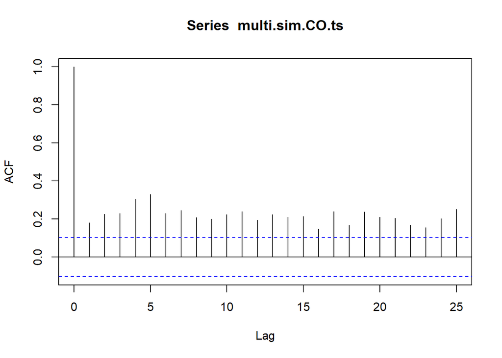

```r
# ACF of simulation
acf(multi.sim.CO.ts)
```

The simulation got close to reproducing the ACF of the time series, though the ACF of the simulation is significant for all of the lags in view and the ACF of the time series cuts off and becomes significant again. Both have some sinusoidal behavior.

```r
# PACF of observations
pacf(CO.ts)
```

[output not shown]

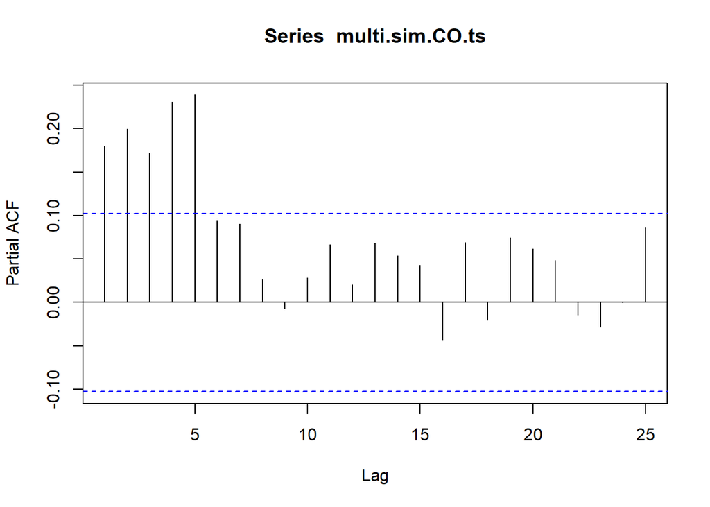

```r
# PACF of simulation
pacf(multi.sim.CO.ts)
```

The PACF of the simulation does not match the PACF of the time series. The PACF of the simulation cuts off after 5 lags, but the PACF of the original time series cuts off after 1 lag and then becomes significant again.

From comparing the ACF and PACF of the time series and simulation, the simulation was somewhat able to reproduce the autocorrelation of the time series.

## Auto-Correlation- NO2

```r
# ACF of observations
acf(NO.ts)
```

[output not shown]

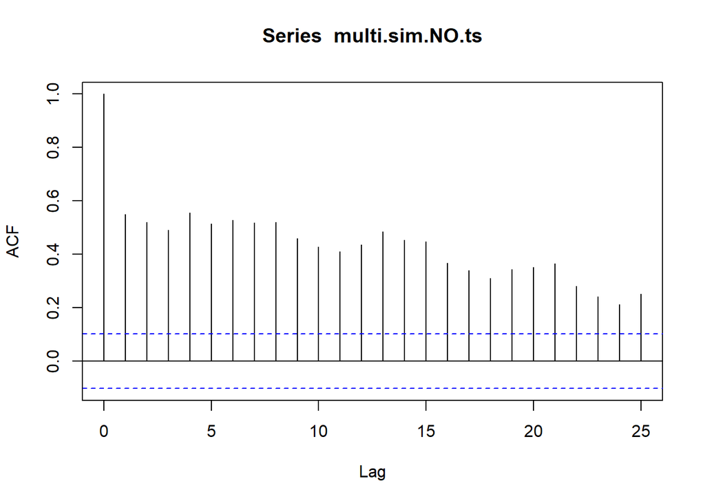

```r
# ACF of simulation
acf(multi.sim.NO.ts)
```

The simulation got very close to reproducing the ACF of the time series. They both are significant for all lags in view on the plot and display some sinusoidal behavior.

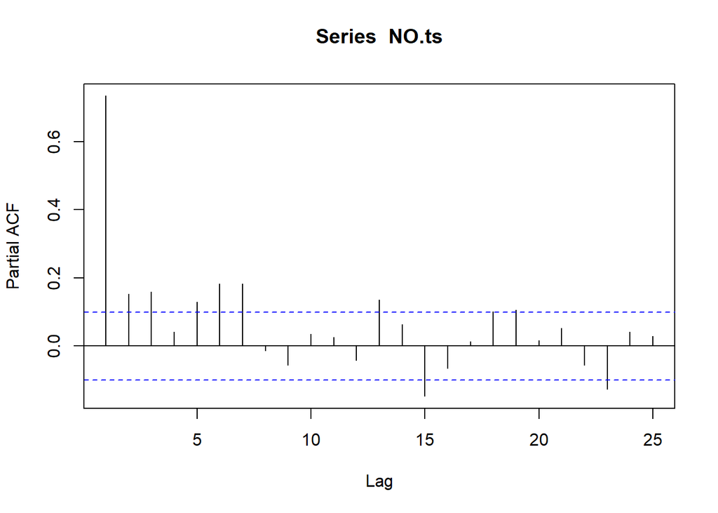

```r
# PACF of observations
pacf(NO.ts)
```

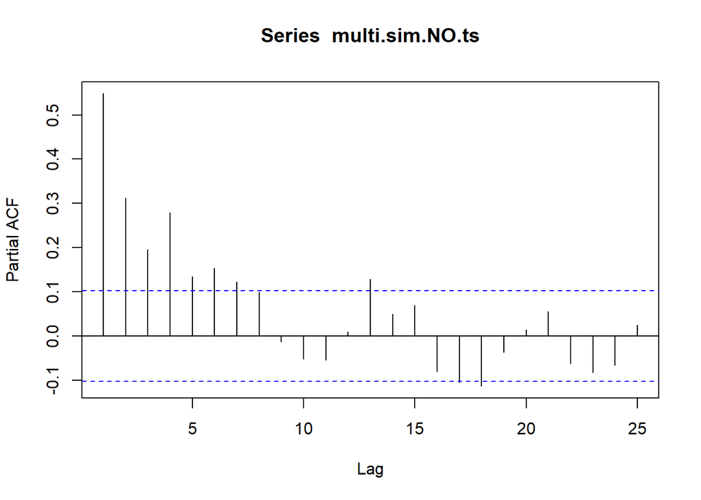

```r
# PACF of simulation
pacf(multi.sim.NO.ts)
```

The ACFs look more similar. The PACF shows more significance at the smaller lags than the original time series.

From comparing the ACF and PACF of the time series and simulation, the simulation was somewhat able to reproduce the autocorrelation of the time series.

# Cross-Correlation

## Cross-Correlation of Time Series

```r
cor(CO.ts, NO.ts)
```

```
## [1] 0.6076964
```

```r
#correlation = 0.608
```

## Cross-Correlation of Univariate Models

```r
cor(CO.uni.sim.ts, NO.uni.sim.ts)
```

```
## [1] 0.1255311
```

```r
#correlation = 0.126
```

## Cross-Correlation of Multivariate Models

```r
cor(multi.sim.CO.ts, multi.sim.NO.ts)
```

```
## [1] 0.5604455
```

```r
#correlation = 0.560
```

The cross-correlation for the original time series is 0.608. The cross-correlation for the univariate models is much lower, at 0.126. The cross-correlation for the multivariate models is 0.560, which is closer to the original value. Using a multivariate model better preserved the correlation between the time series.

# Bonus

### Create forecasts for CO

```r
# create new time data frame
nextweek.time.time <- c(1:(7))
nextweek.time.CO <- data.frame(time.CO = nextweek.time.time)

# create predictions
E_Y.pred.CO <- predict(CO.lm, newdata = nextweek.time.CO)
e_t.pred.CO <- forecast(CO.residuals, h=7)
CO.forecast <- E_Y.pred.CO + e_t.pred.CO$mean
```

### Forecast for NO2

```r
nextweek.time.NO <- data.frame(time.NO = nextweek.time.time)
E_Y.pred.NO <- predict(NO.lm, newdata = nextweek.time.NO)
e_t.pred.NO <- forecast(NO.residuals, h=7)
NO.forecast <- E_Y.pred.NO + e_t.pred.NO$mean
```

### Forecast for CO and NO2 (Multivariate Model)

```r
CO.NO.forecast <- VARMApred(varma.model, h=7)
```

```
## Predictions at origin  384
##  CO.lm.residuals NO.lm.residuals
##        -0.064582         -7.5854
##         0.397990          0.1858
##         0.328284          4.6002
##         0.017780          2.4132
##        -0.153102         -1.0418
##        -0.107949         -2.0728
##         0.008463         -0.9135
## Standard errors of predictions
##       [,1]  [,2]
## [1,] 1.543 30.38
## [2,] 1.664 32.41
## [3,] 1.683 32.59
## [4,] 1.683 32.67
## [5,] 1.689 32.78
## [6,] 1.690 32.86
## [7,] 1.691 32.86
```

```r
e_t.pred.CO.multi <- CO.NO.forecast$pred[,1]
e_t.pred.CO.lower <- CO.NO.forecast$pred[,1] - 1.96*CO.NO.forecast$se.err[,1]
e_t.pred.CO.upper <- CO.NO.forecast$pred[,1] + 1.96*CO.NO.forecast$se.err[,1]
CO.multi.forecast<- E_Y.pred.CO + e_t.pred.CO.multi

e_t.pred.NO.multi <- CO.NO.forecast$pred[,2]
e_t.pred.NO.lower <- CO.NO.forecast$pred[,2] - 1.96*CO.NO.forecast$se.err[,2]
e_t.pred.NO.upper <- CO.NO.forecast$pred[,2] + 1.96*CO.NO.forecast$se.err[,2]
NO.multi.forecast <- E_Y.pred.NO + e_t.pred.NO.multi
```

## Comparison based on MSE

```r
#CO MSE
mean((CO.forecast-air.test$CO.GT.)^2)
```

```
## [1] 4.441717
```

```r
# MSE = 4.71

#NO2 MSE
mean((NO.forecast-air.test$NO2.GT.)^2)
```

```
## [1] 542.948
```

```r
# MSE = 542.95

#CO and NO2 MSE - Multivariate
mean((CO.multi.forecast-air.test$CO.GT.)^2)
```

```
## [1] 4.40135
```

```r
# MSE = 4.40
mean((NO.multi.forecast-air.test$NO2.GT.)^2)
```

```
## [1] 543.2495
```

```r
# MSE = 543.25
```

The MSE for the CO forecast from the univariate model is higher than that from the multivariate model which implies that the multivariate model models the residuals of CO better. Conversely, the MSE for the univariate model for NO2 is smaller than that from the multivariate model which implies that the univariate model does a better job of modeling the residuals of NO2. Despite all this, the MSE between the univariate and multivariate models are very close.

## Visual Comparison

### Forecast from CO Univariate Model

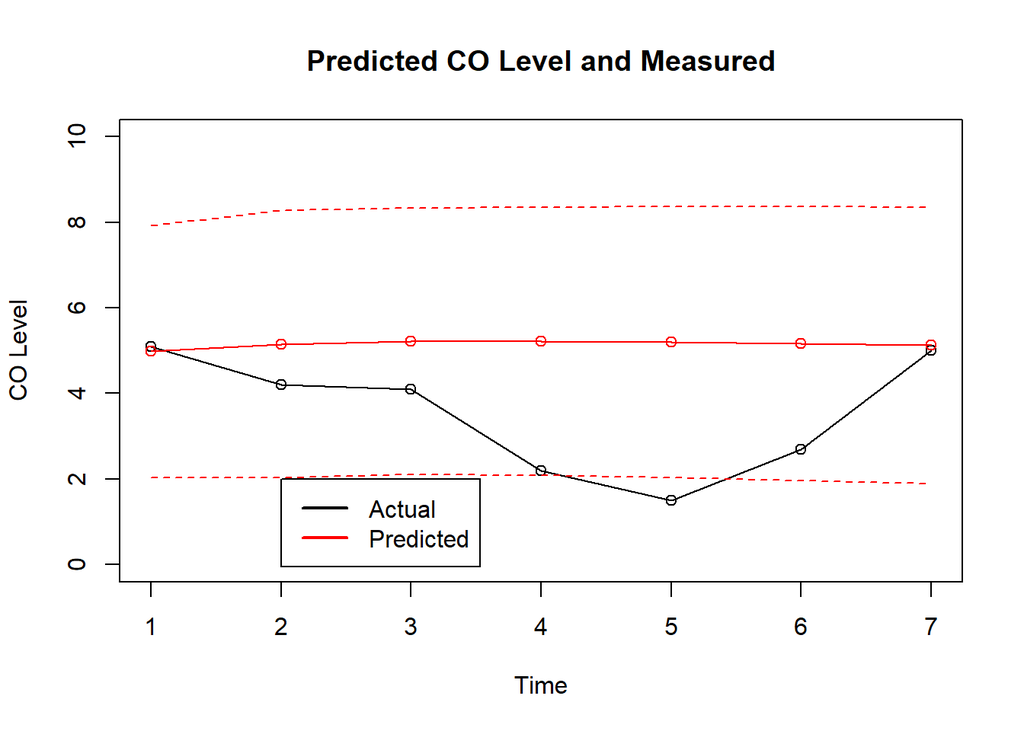

```r
# Plot actual values and predicted values
plot(ts(air.test$CO.GT.),type='o',ylim=c(0,10), ylab="CO Level", main="Predicted CO Level and Measured")
lines(ts(CO.forecast),col='red',type='o')
lines(1:7, E_Y.pred.CO + e_t.pred.CO$lower[,2], col = "red", lty = "dashed")
lines(1:7, E_Y.pred.CO + e_t.pred.CO$upper[,2], col = "red", lty = "dashed")

legend(2,2, legend = c("Actual", "Predicted"), lwd = 2, col = c("black", "red"))
```

### Forecast from NO2 Univariate Model

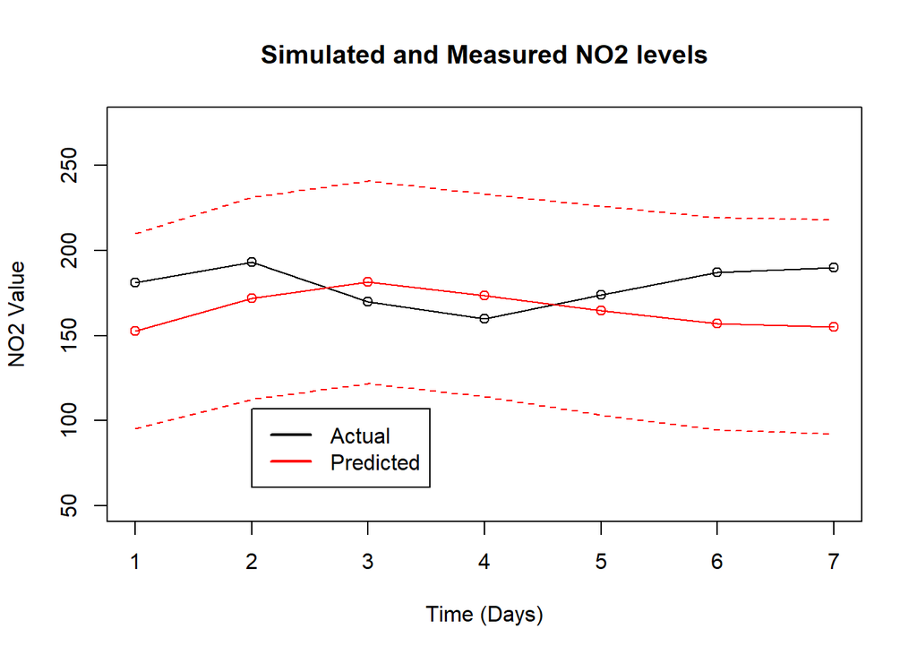

```r
# Plot actual values and predicted values
plot(ts(air.test$NO2.GT.),type='o',ylim=c(50,275), ylab="NO2 Value", xlab="Time (Days)", main="Simulated and Measured NO2 levels")
lines(ts(NO.forecast),col='red',type='o')
lines(1:7, E_Y.pred.NO + e_t.pred.NO$lower[,2], col = "red", lty = "dashed")
lines(1:7, E_Y.pred.NO + e_t.pred.NO$upper[,2], col = "red", lty = "dashed")
legend(2,107, legend = c("Actual", "Predicted"), lwd = 2, col = c("black", "red"))
```

All of the actual values are within the bounds of the confidence interval of the predictions. The actual valyes are higher than the predictions for 5 out of the 7 points.

### Forecast from Multivariate Model

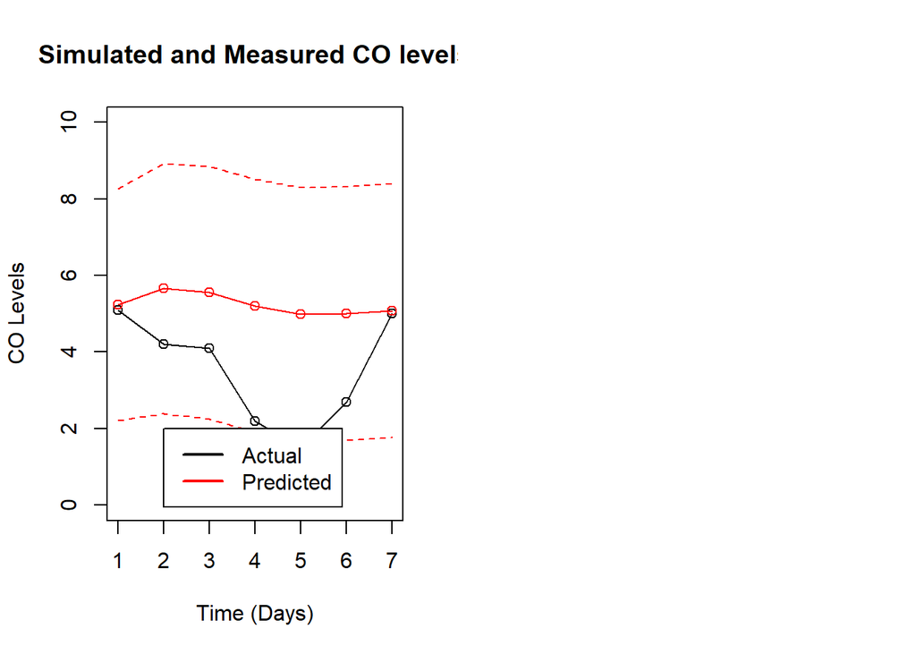

```r
#Multi Plot
par(mfrow=c(1,2))

# CO forecasts
plot(ts(air.test$CO.GT.),type='o', ylim = c(0,10), xlab="Time (Days)", main="Simulated and Measured CO levels", ylab="CO Levels")
lines(ts(CO.multi.forecast),col='red',type='o')
lines(1:7, E_Y.pred.CO + e_t.pred.CO.lower, col = "red", lty = "dashed")
lines(1:7, E_Y.pred.CO + e_t.pred.CO.upper, col = "red", lty = "dashed")
legend(2,2, legend = c("Actual", "Predicted"), lwd = 2, col = c("black", "red"))
```

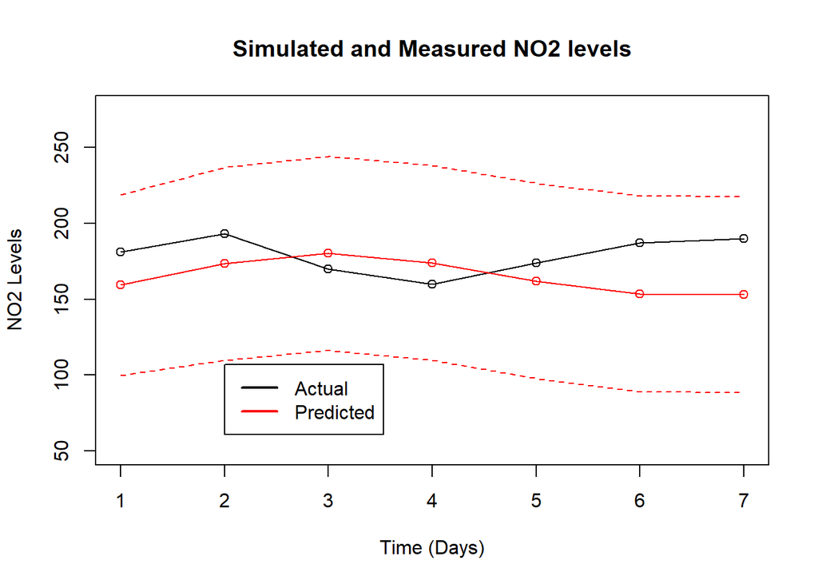

```r
#NO forecasts
plot(ts(air.test$NO2.GT.),type='o',ylim = c(50,275),, xlab="Time (Days)", main="Simulated and Measured NO2 levels", ylab="NO2 Levels")
lines(ts(NO.multi.forecast),col='red',type='o')
lines(1:7, E_Y.pred.NO + e_t.pred.NO.lower, col = "red", lty = "dashed")
lines(1:7, E_Y.pred.NO + e_t.pred.NO.upper, col = "red", lty = "dashed")
legend(2,107, legend = c("Actual", "Predicted"), lwd = 2, col = c("black", "red"))
```

Similar to the univariate model’s forecast, the multivariate model’s forecast for CO predicts that all points are higher than their actual values. There is only one point that is outside the confidence interval and it appears as if it is only just barely outside the interval.

Much like the univariate model, the actual values for NO2 all lie within the multivariate model’s confidence interval. 2 predicted points are less than their predicted values and 5 points are greater than their predicted values.